# Where do non-cognitive skills come from? A within-family analysis of parental inputs, social origin, and sibling personality

Empirical draft: methodology and results

Authors

Affiliations

Garen Avanesian

Southern Federal University, Laboratory for Labor Market Analysis and Monitoring

Ksenia Rozhkova

Higher School of Economics, Laboratory for Labour Market Studies

Abstract

We ask where family resemblance in the Big Five comes from, using up to three assessments per person in the Russian household panel RLMS-HSE. Every assessment of a child is one observation in multilevel models with random intercepts for the settlement, the interview day, the household visit, the family, and the child. Parents’ scores come from before the child’s assessment where the data allow. Siblings correlate at 0.12 to 0.23 in single scores and at 0.30 to 0.70 in the part of a trait that persists across assessments. Parents’ scores account for 11 to 40 percent of what siblings share. Within settlements, one quarter of the income distribution goes with 0.065 standard deviations more openness and 0.042 more agreeableness. Parents’ traits account for 44 and 21 percent of these gradients and for 68 percent of the gradient of openness in the parents’ occupation. Clubs and dance in childhood keep associations of about 0.1 standard deviations with later traits.

**Keywords:** Big Five personality; sibling resemblance; childhood resources; parents’ traits; multilevel models

**JEL codes:** J12, J13, J24, J62

# 1 Introduction

*To be developed.*

# 2 Literature review

*To be developed.*

# 3 Empirical questions

The empirical part answers five questions.

1. **How alike are siblings?** In one score siblings correlate at 0.12 to 0.24. In the part of a trait that persists across assessments they correlate at 0.29 to 0.69, and at 0.21 to 0.55 once what they share through the place they live in is set aside.
2. **How much of this goes with the parents’ traits?** In the persistent part of a trait a mother and her child correlate at 0.21 to 0.54 and a father and his child at 0.21 to 0.61. A parent who scored one standard deviation higher before the child’s assessment has a child who scores 0.10 to 0.21 standard deviations higher. Parents’ scores account for 11 to 40 percent of what siblings share, and for 20 to 53 percent where both parents are scored.
3. **Do children’s traits vary with the family’s resources, and do the parents’ traits account for it?** Among families of the same settlement, one quarter of the income distribution goes with 0.065 standard deviations more openness, 0.042 more agreeableness, and 0.032 more emotional stability. The parents’ traits account for 44 percent of the gradient in openness and 21 percent of the gradient in agreeableness. Children of parents in high-skilled occupations are 0.092 standard deviations more open and 0.101 more conscientious, and the parents’ traits account for 68 and 32 percent of these differences. Where both parents are scored, the mother’s occupation goes with her own trait and not with the father’s.
4. **Does the whole range of the parents’ education matter, and did a degree matter more when it was rare?** Among 18,917 people who report their parents’ education, those whose more educated parent has specialized secondary education are 0.135 standard deviations more open than those whose parents have secondary education or less, and those with a parent in higher education 0.238 more open. For people born before 1960, when 9 percent had such a parent, the difference is 0.323; for people born in 1990 or later, when 39 percent did, it is 0.116.
5. **Are children’s activities related to their later traits?** Children who attended clubs, sections, and courses score 0.069 standard deviations higher in openness and 0.107 in conscientiousness with the parents’ traits held constant. Dance and photography go with 0.080 more openness, 0.097 more extraversion, and 0.088 more agreeableness.

**How to read the estimates.** All estimates are associations. Parents’ traits may be passed on through genes or through upbringing, and the data do not separate the two. The parents’ traits are measured in adulthood, so they may be a channel between the family’s resources and the child’s trait, or they may come first and lead to the parents’ education, occupation, and income. The decomposition in Section 4.6 shows how much of a resource gradient goes with the parents’ traits under either reading.

# 4 Methodology

## 4.1 Data and measurement

We use the Russia Longitudinal Monitoring Survey–Higher School of Economics (RLMS-HSE),[^1] a household panel with records from 1994 to 2025. The Big Five are measured with the 15-item short Big Five Inventory (BFI-S) in the general rounds of 2016, 2020, and 2025 and among entrants between them. We keep one administration per person and period, so a person has at most three assessments. The traits are openness, conscientiousness, extraversion, agreeableness, and emotional stability; higher emotional stability means lower neuroticism. Each score is standardized on all assessments in the data.

The kin file links respondents to their biological parents. A family groups children who share a biological parent. For each assessment we also know the settlement in which the household lives, the day of the interview, and the household.

## 4.2 Samples

Each assessment of a child is one observation (Table 1). The resemblance models use every scored child linked to a biological parent: 17,204 assessments of 8,871 children in 6,806 families and 159 settlements. A parent is scored for 7,765 of these children, and both parents for 3,907. The resource models also need the family’s income, the parents’ education and occupation, and the controls, which leaves 5,274 children, of whom 3,177 have both parents.

Table 1: Samples

| Sample | Assessments | Children | Families | Settlements |
| --- | --- | --- | --- | --- |
| All children linked to a biological parent | 17,204 | 8,871 | 6,806 | 159 |
| A parent scored | 14,914 | 7,765 | 5,789 | 159 |
| Both parents scored | 7,266 | 3,907 | 2,741 | 153 |
| Resource models, parents pooled | 9,834 | 5,274 | 3,822 | 155 |
| Resource models, mother and father | 5,817 | 3,177 | 2,230 | 150 |

*Notes:* Each observation is one assessment of a child. A parent was scored before the child's assessment in 57 percent of the assessments with a scored parent and in 60 percent of those in the pooled resource sample; in the others the parent's score comes from the same round or, in about 1 percent, from a later one.

The children are young people: the Big Five are asked from age 14, and the mean age at the first assessment is 21.6 years (Table 2). A child has 1.9 assessments on average.

Table 2: Children in the resource samples

|  | Parents pooled | Both parents |
| --- | --- | --- |
| Children | 5,274 | 3,177 |
| Assessments | 9,834 | 5,817 |
| Female | 0.50 | 0.49 |
| Age at first assessment, mean | 21.6 | 20.7 |
| Age at first assessment, 10th percentile | 14.0 | 14.0 |
| Age at first assessment, 90th percentile | 33.5 | 32.0 |
| Assessments per child | 1.9 | 1.8 |
| Household income rank in childhood (0-1) | 0.51 | 0.52 |
| Either parent has a degree | 0.37 | 0.41 |
| Mother has a degree | 0.31 | 0.33 |
| Father has a degree | 0.23 | 0.25 |
| Either parent in a high-skilled occupation | 0.47 | 0.51 |
| Mother in a high-skilled occupation | 0.40 | 0.42 |
| Father in a high-skilled occupation | 0.23 | 0.25 |
| Grew up in a city or regional center | 0.64 | 0.61 |
| Recorded sibship size | 2.2 | 2.3 |
| Registered disability by first assessment | 0.03 | 0.03 |
| Only the mother's records observed | 0.25 | 0.00 |
| A parent scored before one of the child's assessments | 0.77 | 0.80 |

*Notes:* Means unless stated. Mother's and father's rows use the children for whom that parent's education and occupation are recorded. Household income is income per person ranked within the survey year and averaged over the childhood waves.

## 4.3 The model

The models are shown as the R calls that fit them (package `lme4`). The calls are written for openness; the scripts named above each block repeat them for the five traits. Each row of `rows` is one assessment of a child, and the outcome is the child’s score.

```
sub/code/02_resemblance.R
```

```r
library(lme4)
# null model: no regressors
null <- lmer(O ~ 1 +
               (1 | site) + (1 | day) + (1 | visit) + (1 | fam) + (1 | pid),
             data = rows)
# model with the sociodemographic controls
ctrl <- lmer(O ~ female + age10 + age10_sq + age10_cu + round +
               (1 | site) + (1 | day) + (1 | visit) + (1 | fam) + (1 | pid),
             data = rows)
```

The model has five random intercepts. `site` is common to everyone in a settlement, `day` to the interviews held in the settlement on the same day, `visit` to the members of a household interviewed in the same round, `fam` to the children of a family, and `pid` is the child’s own lasting departure from the family. The residual belongs to the single assessment and includes passing moods as well as reporting error. The controls are sex (`female`), a cubic in age (`age10`, `age10_sq`, `age10_cu`), and the round. All later models add regressors to this one and keep the same random intercepts.

The settlement intercept takes out regional differences and any local habit of answering in a similar way. The estimates for families are therefore comparisons of families within the same place.

We estimate this model twice: as a null model with no regressors, which gives the variance of a score at each level, and with the sociodemographic controls. The two are reported side by side.

Siblings share the settlement and the family. The sibling correlations are ratios of the variances of the fitted model: what siblings share over the total variance (single scores), and over the variance that persists across assessments.

```
sub/code/02_resemblance.R
```

```r
# variance of each random intercept and of the residual
v <- as.data.frame(VarCorr(ctrl)); v <- setNames(v$vcov, v$grp)
shared <- v["site"] + v["fam"]              # what siblings share
shared / sum(v)                             # sibling correlation in single scores
shared / (shared + v["pid"])                # in the part of the trait that persists
v["fam"] / (v["fam"] + v["pid"])            # the same with the settlement left out
```

The correlation between a parent and a child comes from the same kind of model. A parent and all of his or her children form one group, and the assessments of the parent and of the children are the observations. One intercept is shared by the parent and the children and a second one by the children only; parents and children have their own person variances. The parent-child correlation in the persistent part is the variance that parent and child share, the settlement and the common intercept, divided by the square root of the product of the two persistent variances. The mother’s and the father’s models are estimated separately.

```
sub/code/02_resemblance.R
```

```r
# pc: the assessments of a parent (parent = 1, child = 0) and of all of his or her
# children (child = 1, parent = 0); grp and grp2 hold the parent's id, pid and pid2
# the person's id
m <- lmer(O ~ child + (1 | site) + (1 | day) + (1 | visit) +
            (1 | grp) +                 # shared by the parent and the children
            (0 + child | grp2) +        # shared by the children only
            (0 + child | pid) +         # a child's own persistent part
            (0 + parent | pid2),        # the parent's own persistent part
          data = pc)
v <- as.data.frame(VarCorr(m)); v <- setNames(v$vcov, v$grp)
a <- v["site"] + v["grp"]
# parent-child correlation in the persistent part
a / sqrt((a + v["pid2"]) * (a + v["grp2"] + v["pid"]))
```

## 4.4 Parents’ traits

A parent has one to three scores, and a score taken on the same visit as the child’s resembles it more than a score taken on another occasion. Mothers and children scored in the same household visit correlate at 0.22 to 0.40 across the five traits, and the same mothers and children scored in different rounds at 0.11 to 0.22; for siblings the figures are 0.24 to 0.44 and 0.07 to 0.21 (Figure 7 in the Appendix). Two unrelated people from different households of a settlement who were interviewed on the same day correlate at 0.15 in openness and 0.17 in agreeableness. A shared visit thus adds resemblance that has nothing to do with the family, and a model that relates a child’s score to a parent’s score from the same visit would count it as transmission. We therefore use, for each assessment of the child, the parent’s score from before that assessment: the mean of the parent’s scores from earlier rounds. Where the parent has no earlier score we use the score from the same round, and in the few remaining cases a later one. These two kinds of scores enter as separate regressors, with an indicator for the second kind, so that the coefficient of interest refers to a parent scored before the child. Parents’ scores are taken relative to people of the same sex and age in the same round.

```
sub/code/01_sample.R
```

```r
# every scored person: the score relative to people of the same sex and age
# in the same round
scores$O <- resid(lm(O ~ female * (age10 + age10_sq + age10_cu) + factor(round),
                     data = scores))
# for the child's assessment in round r; x holds the parent's rounds and scores
before <- x$round < r; same <- x$round == r
# scored before the child's assessment: mean of the earlier scores
p_O_B  <- if (any(before)) mean(x$O[before]) else 0
# otherwise the score of the same round, or failing that a later one
p_O_S  <- if (any(before)) 0 else if (any(same)) x$O[same] else mean(x$O)
# indicator of the second kind
p_same <- as.integer(!any(before))
```

In the pooled models the parents’ score is the mean over the parents who were scored before the child’s assessment and, if neither was, over the parents scored in the same round. In the models for both parents the mother’s and the father’s scores enter separately.

The part of sibling resemblance that goes with the parents’ traits is the fall in the settlement and family variance when the parents’ scores are added, as a share of its value without them.

```
sub/code/02_resemblance.R
```

```r
d  <- rows[rows$p_scored, ]                       # children with a scored parent
c0 <- lmer(O ~ female + age10 + age10_sq + age10_cu + round +
             (1 | site) + (1 | day) + (1 | visit) + (1 | fam) + (1 | pid),
           data = d)
c1 <- update(c0, . ~ . + p_O_B + p_O_S + p_same)  # parents pooled
# both parents scored: + m_O_B + m_O_S + m_same + f_O_B + f_O_S + f_same
v0 <- as.data.frame(VarCorr(c0)); v0 <- setNames(v0$vcov, v0$grp)
v1 <- as.data.frame(VarCorr(c1)); v1 <- setNames(v1$vcov, v1$grp)
# the parents' part of what siblings share
1 - (v1["site"] + v1["fam"]) / (v0["site"] + v0["fam"])
```

## 4.5 Resources in childhood

Resources are measured in the survey waves before the child’s first assessment in which the child was under 19; for children with no such wave the window extends to under 25. Household income is income per person, ranked within the survey year and averaged over the window; coefficients are per quarter of the rank. A parent has a degree if the latest record in the window shows tertiary education. A parent is in a high-skilled occupation if at least half of the observed waves show a job in major groups 1 to 3 of the International Standard Classification of Occupations 2008.

The pooled models use indicators equal to one if either parent with records meets the criterion, with indicators for children for whom only one parent’s records exist. The models for both parents enter the mother’s and the father’s education and occupation separately. Both control for urban residence in childhood, registered disability by the first assessment, sibship size, birth order, and the share of brothers.

Two choices in these definitions are checked in the Appendix. The first is the measure of money: we replace household income by the parents’ earnings, each parent ranked among mothers or fathers within the year, with no job counted as the lowest rank. The second is the window: we fix it at under 19 and at under 25 for all children (Table 9; Table 10).

## 4.6 Resources and the parents’ traits

If families pass on their position partly through traits (Bowles and Gintis, 2002), a resource gradient in the child’s trait should become smaller when the parents’ trait is held constant. For each resource we report three quantities. The total is the resource’s coefficient in the model without the parents’ traits. The direct part is its coefficient with them. The part that goes with the parents’ traits is the difference. In the terms of mediation analysis (Imai et al., 2010) these are the total effect, the average direct effect (ADE), and the average causal mediation effect (ACME). We give the share of the total only where the total differs from zero at the 5 percent level and the direct part has the same sign.

In the models for both parents, a parent’s part is the fall in the resource’s coefficient when that parent’s trait is added, averaged over the two orders in which the parents can be added. Household income belongs to both parents, so we report the mother’s and the father’s part; they add up to the difference exactly. For a parent’s own education and occupation we report only the part that goes with that parent’s own trait, and the direct part is the rest of the total.

Standard errors for these quantities, for the sibling correlations, and for the parents’ share come from 200 bootstrap samples of settlements, the highest level of the model.

```
sub/code/04_mediation.R
```

```r
# m0: the resource model without the parents' traits; m1: with them
# (both calls are shown above the resource tables)
total   <- fixef(m0)["hinc_q"]
direct  <- fixef(m1)["hinc_q"]                 # ADE
through <- total - direct                      # ACME
# mother and father entered separately: a parent's part, averaged over the two
# orders of adding the parents
bm <- fixef(update(m0, . ~ . + m_O_B + m_O_S + m_same))["hinc_q"]   # mother only
bf <- fixef(update(m0, . ~ . + f_O_B + f_O_S + f_same))["hinc_q"]   # father only
through_mother <- ((total - bm) + (bf - direct)) / 2
through_father <- ((total - bf) + (bm - direct)) / 2
# one bootstrap sample: settlements drawn with replacement, with everyone in them
boot_sites <- function(d) {
  s <- sample(unique(d$site), replace = TRUE)
  do.call(rbind, lapply(seq_along(s), function(k) {
    b <- d[d$site == s[k], ]
    for (g in c("site", "day", "visit", "fam", "pid")) b[[g]] <- paste(k, b[[g]])
    b }))
}
```

A causal reading needs two conditions that the data cannot guarantee: the resource must be unrelated to other causes of the child’s trait given the controls, and so must the parents’ trait given the resource and the controls. The order of the two is also open (Section 3).

## 4.7 Parents’ education in the larger sample

The resource models test one contrast in the parents’ education, a degree against no degree, because they are limited to children whose parents are in the panel. To see the whole range we turn to a question asked of every adult respondent in 2018 and 2025: what education the father and the mother had. 18,917 people with a trait score answered it, with 41,037 assessments. Most of their parents are not in the panel, so these models do not include the parents’ traits.

We take the education of the more educated parent in four levels: secondary or below (general secondary school, vocational school, or less), specialized secondary, higher, and postgraduate study or an academic degree. The last level is small: 87 people. In a second version education enters as years of schooling: 8 for incomplete secondary school, 11 for secondary school, 13 for specialized secondary, 16 for higher education, and 19 for postgraduate study or a degree. We fit the years as a straight line, with a squared term, and as a flexible curve, and test the last two against the straight line. The model is the one of Section 4.3 with random intercepts for the settlement, the interview day, the household visit, and the person.

To see whether a parent’s degree mattered more when degrees were rare, we interact the levels with the respondent’s birth cohort (before 1960, 1960 to 1974, 1975 to 1989, 1990 or later) and test whether the education coefficients are the same in all cohorts. Older cohorts are also assessed at older ages, so a difference between cohorts can also be a difference between ages.

## 4.8 Children’s activities

The child questionnaires answered by an adult of the household before the child turned 18 and before the first assessment record seven activities: clubs, sections, and courses; dance or photography; drawing or music; foreign languages; technical clubs; visits to theaters, museums, and exhibitions; and outings with peers. An activity is measured as the share of the questionnaires that record it. The seven activities enter the pooled resource model together, with the mean age at the reports and their number, so each coefficient compares a child who took part in half of the reports with one who never did, with the other six activities held constant. Children who dance are more likely to attend clubs as well (the correlation is 0.33), and a model with one activity at a time would give each the credit of the others. We estimate each model without and with the parents’ traits, among children with all seven activities recorded.

# 5 Results

## 5.1 The variance of a score and the resemblance between kin

About half of the variance of one score belongs to the single assessment: 39.1 to 48.2 percent in the null model (Table 3). The household visit holds a further 9.6 to 15.8 percent. For openness and agreeableness the settlement holds about as much variance as the family. Sex, age, and the round explain 1 to 8 percent of the variance of a score and change the variance components little.

```
sub/code/02_resemblance.R
```

```r
# null model: no regressors
null <- lmer(O ~ 1 +
               (1 | site) + (1 | day) + (1 | visit) + (1 | fam) + (1 | pid),
             data = rows)
# model with the sociodemographic controls
ctrl <- lmer(O ~ female + age10 + age10_sq + age10_cu + round +
               (1 | site) + (1 | day) + (1 | visit) + (1 | fam) + (1 | pid),
             data = rows)
```

Table 3: The null model and the model with sociodemographic controls

| Variable | Openness Null | Openness Controls | Conscientiousness Null | Conscientiousness Controls | Extraversion Null | Extraversion Controls | Agreeableness Null | Agreeableness Controls | Emotional stability Null | Emotional stability Controls |
| --- | --- | --- | --- | --- | --- | --- | --- | --- | --- | --- |
| Female | – | 0.226*** | – | 0.260*** | – | 0.238*** | – | 0.179*** | – | −0.360*** |
|  |  | (0.016) |  | (0.017) |  | (0.017) |  | (0.016) |  | (0.016) |
| Age, decades from 20 | – | 0.031* | – | 0.487*** | – | −0.120*** | – | 0.043** | – | −0.073*** |
|  |  | (0.017) |  | (0.018) |  | (0.018) |  | (0.017) |  | (0.018) |
| Age squared | – | −0.041*** | – | −0.160*** | – | 0.004 | – | −0.019* | – | 0.006 |
|  |  | (0.010) |  | (0.010) |  | (0.011) |  | (0.010) |  | (0.010) |
| Age cubed | – | 0.003** | – | 0.013*** | – | 0.001 | – | 0.003** | – | −0.001 |
|  |  | (0.001) |  | (0.001) |  | (0.001) |  | (0.001) |  | (0.001) |
| Round 2020 | – | −0.001 | – | −0.014 | – | 0.018 | – | 0.013 | – | 0.134*** |
|  |  | (0.017) |  | (0.016) |  | (0.016) |  | (0.018) |  | (0.017) |
| Round 2025 | – | 0.094*** | – | 0.003 | – | −0.008 | – | −0.076*** | – | 0.296*** |
|  |  | (0.018) |  | (0.018) |  | (0.017) |  | (0.019) |  | (0.018) |
| Constant | −0.028 | −0.083** | −0.130*** | −0.398*** | 0.029 | 0.011 | −0.061** | −0.161*** | 0.054*** | 0.206*** |
|  | (0.031) | (0.033) | (0.024) | (0.027) | (0.022) | (0.026) | (0.030) | (0.033) | (0.018) | (0.022) |
| **Random part, fit, and sample** |  |  |  |  |  |  |  |  |  |  |
| Variance: settlement | 0.115 | 0.107 | 0.053 | 0.054 | 0.043 | 0.043 | 0.104 | 0.106 | 0.022 | 0.021 |
| Variance: interview day | 0.067 | 0.064 | 0.027 | 0.023 | 0.010 | 0.011 | 0.061 | 0.059 | 0.042 | 0.024 |
| Variance: household visit | 0.130 | 0.136 | 0.098 | 0.119 | 0.106 | 0.104 | 0.157 | 0.159 | 0.146 | 0.148 |
| Variance: family | 0.123 | 0.112 | 0.168 | 0.121 | 0.079 | 0.073 | 0.113 | 0.110 | 0.120 | 0.084 |
| Variance: child | 0.157 | 0.143 | 0.181 | 0.162 | 0.294 | 0.272 | 0.099 | 0.090 | 0.174 | 0.156 |
| Variance: residual | 0.380 | 0.378 | 0.489 | 0.454 | 0.447 | 0.447 | 0.458 | 0.458 | 0.468 | 0.472 |
| Share, percent: settlement | 11.8 | 11.4 | 5.2 | 5.8 | 4.4 | 4.6 | 10.5 | 10.8 | 2.2 | 2.4 |
| Share, percent: interview day | 6.9 | 6.8 | 2.6 | 2.4 | 1.1 | 1.2 | 6.2 | 6.0 | 4.3 | 2.6 |
| Share, percent: household visit | 13.4 | 14.4 | 9.6 | 12.8 | 10.9 | 11.0 | 15.8 | 16.1 | 15.0 | 16.4 |
| Share, percent: family | 12.6 | 11.9 | 16.6 | 12.9 | 8.0 | 7.6 | 11.4 | 11.2 | 12.3 | 9.3 |
| Share, percent: child | 16.2 | 15.2 | 17.8 | 17.4 | 30.0 | 28.6 | 9.9 | 9.2 | 17.9 | 17.2 |
| Share, percent: residual | 39.1 | 40.2 | 48.1 | 48.7 | 45.6 | 47.0 | 46.2 | 46.7 | 48.2 | 52.1 |
| Sibling correlation, single scores | 0.24 | 0.23 | 0.22 | 0.19 | 0.12 | 0.12 | 0.22 | 0.22 | 0.15 | 0.12 |
| Sibling correlation, persistent part | 0.60 | 0.61 | 0.55 | 0.52 | 0.29 | 0.30 | 0.69 | 0.70 | 0.45 | 0.40 |
| Sibling correlation, persistent part, family only | 0.44 | 0.44 | 0.48 | 0.43 | 0.21 | 0.21 | 0.53 | 0.55 | 0.41 | 0.35 |
| Marginal R-squared | 0.000 | 0.027 | 0.000 | 0.083 | 0.000 | 0.029 | 0.000 | 0.011 | 0.000 | 0.063 |
| Conditional R-squared | 0.609 | 0.609 | 0.519 | 0.554 | 0.544 | 0.544 | 0.538 | 0.539 | 0.518 | 0.511 |
| Log-likelihood | −22,295 | −22,098 | −23,282 | −22,649 | −22,968 | −22,778 | −22,866 | −22,775 | −23,252 | −22,801 |
| AIC | 44,603 | 44,223 | 46,577 | 45,323 | 45,950 | 45,581 | 45,745 | 45,576 | 46,518 | 45,628 |
| BIC | 44,657 | 44,324 | 46,631 | 45,424 | 46,004 | 45,682 | 45,799 | 45,677 | 46,572 | 45,729 |
| Assessments | 17,204 | 17,204 | 17,204 | 17,204 | 17,204 | 17,204 | 17,204 | 17,204 | 17,204 | 17,204 |
| Children | 8,871 | 8,871 | 8,871 | 8,871 | 8,871 | 8,871 | 8,871 | 8,871 | 8,871 | 8,871 |
| Families | 6,806 | 6,806 | 6,806 | 6,806 | 6,806 | 6,806 | 6,806 | 6,806 | 6,806 | 6,806 |
| Settlements | 159 | 159 | 159 | 159 | 159 | 159 | 159 | 159 | 159 | 159 |

*Notes:* Outcome: the child's score at each assessment, in standard deviations. Multilevel models with random intercepts for the settlement, the interview day within the settlement, the household visit, the family, and the child. Null: no regressors. Controls: sex, a cubic in age, and the round. Sibling correlation in single scores: settlement and family variance over the total variance; persistent part: the same over the settlement, family, and child variance. Marginal R-squared: variance of the fixed part over the total; conditional: fixed part and random intercepts over the total. Log-likelihood, AIC, and BIC from the maximum-likelihood fit. Standard errors in parentheses. * p < 0.10, ** p < 0.05, *** p < 0.01.

In single scores kin therefore look weakly alike (Figure 1). Siblings correlate at 0.12 to 0.24, mothers and children at 0.07 to 0.21, and fathers and children at 0.08 to 0.20. In the part of a trait that persists across assessments the correlations are 0.29 to 0.69 for siblings, 0.21 to 0.54 for mothers and children, and 0.21 to 0.61 for fathers and children. Kin are most alike in agreeableness and openness. Children resemble their mothers and their fathers to a similar degree. In openness and agreeableness they resemble a parent almost as much as a sibling; in conscientiousness and emotional stability they resemble a parent less. With sex, age, and the round held constant the correlations are similar (Table 4); those for conscientiousness rise, because conscientiousness increases with age. Leaving the settlement out lowers the sibling correlation to 0.21 to 0.55.

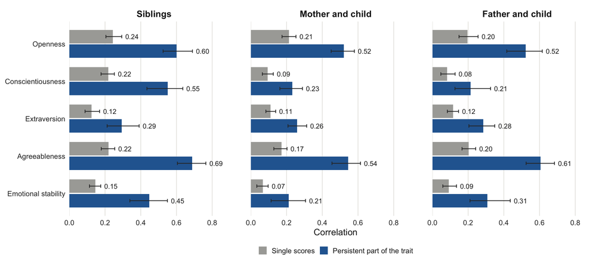

Figure 1: Resemblance between kin in single scores and in the persistent part of the trait. Correlations from null multilevel models with random intercepts for the settlement, the interview day, the household visit, the family, and the person. Lines are 95 percent intervals from 200 bootstrap samples of settlements.

```
sub/code/02_resemblance.R
```

```r
# sibling correlations: variance ratios of null and ctrl (see the methodology)
# parents' coefficients, children with a scored parent
c1 <- lmer(O ~ p_O_B + p_O_S + p_same +
             female + age10 + age10_sq + age10_cu + round +
             (1 | site) + (1 | day) + (1 | visit) + (1 | fam) + (1 | pid),
           data = rows[rows$p_scored, ])
# both parents scored
c2 <- lmer(O ~ m_O_B + m_O_S + m_same + f_O_B + f_O_S + f_same +
             female + age10 + age10_sq + age10_cu + round +
             (1 | site) + (1 | day) + (1 | visit) + (1 | fam) + (1 | pid),
           data = rows[rows$m_scored & rows$f_scored, ])
```

Table 4: Resemblance between kin and the part that goes with the parents’ scores

|  | O | C | E | A | ES |
| --- | --- | --- | --- | --- | --- |
| **Correlations, null models** |  |  |  |  |  |
| Siblings, single scores | 0.24 (0.02) | 0.22 (0.02) | 0.12 (0.02) | 0.22 (0.02) | 0.15 (0.02) |
| Siblings, persistent part | 0.60 (0.04) | 0.55 (0.05) | 0.29 (0.05) | 0.69 (0.04) | 0.45 (0.05) |
| Mother and child, single scores | 0.21 (0.02) | 0.09 (0.02) | 0.11 (0.01) | 0.17 (0.02) | 0.07 (0.02) |
| Mother and child, persistent part | 0.52 (0.03) | 0.23 (0.03) | 0.26 (0.03) | 0.54 (0.04) | 0.21 (0.05) |
| Father and child, single scores | 0.20 (0.03) | 0.08 (0.02) | 0.12 (0.02) | 0.20 (0.02) | 0.09 (0.02) |
| Father and child, persistent part | 0.52 (0.05) | 0.21 (0.05) | 0.28 (0.04) | 0.61 (0.04) | 0.31 (0.06) |
| **Correlations, with sex, age, and round** |  |  |  |  |  |
| Siblings, single scores | 0.23 (0.02) | 0.19 (0.02) | 0.12 (0.02) | 0.22 (0.02) | 0.12 (0.02) |
| Siblings, persistent part | 0.61 (0.04) | 0.52 (0.05) | 0.30 (0.05) | 0.70 (0.05) | 0.40 (0.06) |
| Siblings, persistent part, family only | 0.44 (0.06) | 0.43 (0.06) | 0.21 (0.05) | 0.55 (0.06) | 0.35 (0.06) |
| Mother and child, single scores | 0.20 (0.02) | 0.12 (0.01) | 0.10 (0.01) | 0.17 (0.02) | 0.05 (0.02) |
| Mother and child, persistent part | 0.53 (0.03) | 0.34 (0.03) | 0.24 (0.03) | 0.55 (0.04) | 0.18 (0.05) |
| Father and child, single scores | 0.20 (0.03) | 0.13 (0.02) | 0.11 (0.02) | 0.20 (0.02) | 0.09 (0.02) |
| Father and child, persistent part | 0.54 (0.05) | 0.36 (0.05) | 0.27 (0.04) | 0.61 (0.04) | 0.31 (0.06) |
| **Coefficient of the parents' score in the child's model, parents pooled** |  |  |  |  |  |
| Parents scored before the child's assessment | 0.208 (0.024) | 0.162 (0.019) | 0.150 (0.015) | 0.180 (0.017) | 0.102 (0.018) |
| Parents scored in the same round | 0.302 (0.020) | 0.180 (0.020) | 0.178 (0.015) | 0.255 (0.017) | 0.163 (0.021) |
| **Coefficient of the parent's score in the child's model, mother and father together** |  |  |  |  |  |
| Mother, scored before | 0.165 (0.021) | 0.168 (0.021) | 0.094 (0.019) | 0.145 (0.020) | 0.085 (0.021) |
| Mother, same round | 0.238 (0.021) | 0.136 (0.020) | 0.127 (0.023) | 0.250 (0.020) | 0.136 (0.025) |
| Father, scored before | 0.105 (0.019) | 0.092 (0.019) | 0.093 (0.017) | 0.102 (0.018) | 0.082 (0.018) |
| Father, same round | 0.189 (0.017) | 0.177 (0.023) | 0.123 (0.024) | 0.193 (0.020) | 0.133 (0.023) |
| **Part of what siblings share that goes with the parents' scores, percent** |  |  |  |  |  |
| Parents pooled | 40 (4) | 20 (3) | 30 (8) | 25 (3) | 11 (3) |
| Mother and father | 53 (6) | 28 (4) | 34 (11) | 36 (4) | 20 (4) |

*Notes:* Correlations from multilevel models: the variance two relatives share (settlement and family) over the total variance (single scores) or over the persistent variance (settlement, family, and person). Parents' part: fall in the settlement and family variance of the children's model when the parents' scores are added. Siblings: 8,871 children; mothers and children: 7,494 children; fathers and children: 4,178; parents pooled: 7,765; mother and father: 3,907. Standard errors from 200 bootstrap samples of settlements in parentheses.

## 5.2 How much goes with the parents’ traits?

A parent who scored one standard deviation higher before the child’s assessment has a child who scores 0.10 to 0.21 standard deviations higher in a single assessment (Table 4). The coefficient for a parent scored in the same round is larger in every trait, 0.16 to 0.30. The difference measures what a shared interview adds to the resemblance. With both parents in the model the mother’s coefficient is 0.08 to 0.17 and the father’s 0.08 to 0.10.

The parents’ scores account for 40 percent of what siblings share in openness and for 11 to 30 percent in the other traits (Figure 2). With both parents scored the shares are 20 to 53 percent. These shares are conservative, because one or two scores measure a parent’s trait with error. The remainder is what siblings share beyond their parents’ measured traits, inherited or not.

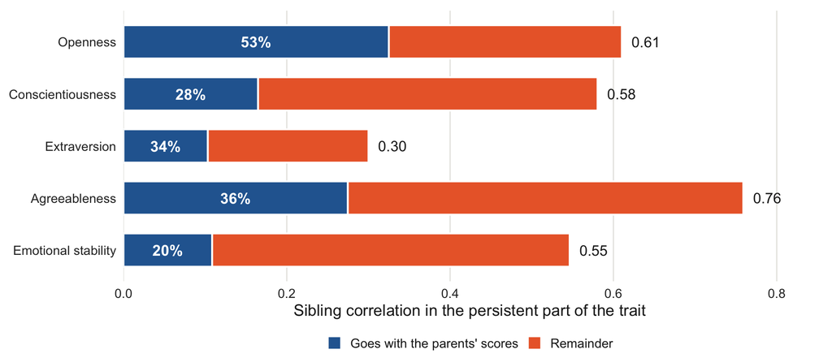

Figure 2: Sibling resemblance and the part that goes with the parents’ scores. Bars: sibling correlation in the persistent part of the trait among children with both parents scored, from the multilevel model with sex, age, and round. Blue: the part that goes with the mother’s and the father’s scores, with its share in percent; orange: the remainder.

## 5.3 Resources and children’s traits

Among families of the same settlement, children from higher-income families are more open, more agreeable, and more emotionally stable (Table 5, columns without the parents’ traits). One quarter of the income distribution goes with 0.065 standard deviations of openness, 0.042 of agreeableness, and 0.032 of emotional stability. For comparison, the difference between women and men in openness in the same model is 0.18. The gradients in conscientiousness (0.018) and extraversion (0.026) are not clearly different from zero. A parent with a degree goes with 0.109 more openness, and a parent in a high-skilled occupation with 0.092 more openness and 0.101 more conscientiousness.

With the parents’ traits in the model the income coefficient for openness falls to 0.037 and stays different from zero (p = 0.010). The coefficient for agreeableness falls to 0.034 and the one for emotional stability to 0.028. The degree coefficient for openness falls from 0.109 to 0.072. The occupation coefficient falls from 0.092 to 0.029 for openness, where it is no longer distinguishable from zero, and from 0.101 to 0.069 for conscientiousness.

```
sub/code/03_resources.R
```

```r
a  <- rows[rows$in_A, ]                         # resource sample, parents pooled
m0 <- lmer(O ~ hinc_q + p_tert + p_wc + settle + only_mother + only_father +
             disabled_by_first + recorded_sibship_size + recorded_birth_order +
             share_brothers +
             female + age10 + age10_sq + age10_cu + round +
             (1 | site) + (1 | day) + (1 | visit) + (1 | fam) + (1 | pid),
           data = a)
m1 <- update(m0, . ~ . + p_O_B + p_O_S + p_same)         # with the parents' traits
```

Table 5: Childhood resources and the child’s traits, without and with the parents’ traits: parents pooled

| Variable | Openness Without | Openness With | Conscientiousness Without | Conscientiousness With | Extraversion Without | Extraversion With | Agreeableness Without | Agreeableness With | Emotional stability Without | Emotional stability With |
| --- | --- | --- | --- | --- | --- | --- | --- | --- | --- | --- |
| Parents' score, before the child's assessment | – | 0.214*** | – | 0.166*** | – | 0.165*** | – | 0.195*** | – | 0.115*** |
|  |  | (0.016) |  | (0.017) |  | (0.016) |  | (0.016) |  | (0.016) |
| Parents' score, same round | – | 0.300*** | – | 0.235*** | – | 0.207*** | – | 0.299*** | – | 0.176*** |
|  |  | (0.017) |  | (0.019) |  | (0.017) |  | (0.017) |  | (0.017) |
| Parents scored in the same round only | – | 0.084 | – | 0.116** | – | 0.033 | – | 0.053 | – | 0.210*** |
|  |  | (0.054) |  | (0.056) |  | (0.056) |  | (0.057) |  | (0.056) |
| Household income rank, per quarter | 0.065*** | 0.037** | 0.018 | 0.004 | 0.026* | 0.011 | 0.042*** | 0.034** | 0.032** | 0.028* |
|  | (0.015) | (0.014) | (0.015) | (0.015) | (0.015) | (0.015) | (0.015) | (0.015) | (0.015) | (0.014) |
| Either parent: tertiary degree | 0.109*** | 0.072*** | −0.011 | −0.011 | −0.019 | −0.021 | 0.031 | 0.039 | 0.024 | 0.002 |
|  | (0.028) | (0.027) | (0.029) | (0.028) | (0.030) | (0.029) | (0.028) | (0.027) | (0.028) | (0.027) |
| Either parent: high-skilled occupation | 0.092*** | 0.029 | 0.101*** | 0.069*** | 0.014 | 0.011 | 0.021 | −0.005 | 0.030 | 0.018 |
|  | (0.026) | (0.025) | (0.027) | (0.027) | (0.028) | (0.027) | (0.027) | (0.026) | (0.026) | (0.026) |
| Urban childhood residence | 0.071 | 0.007 | −0.052 | −0.068 | 0.099** | 0.088** | −0.022 | −0.037 | −0.058 | −0.055 |
|  | (0.055) | (0.044) | (0.051) | (0.044) | (0.042) | (0.036) | (0.068) | (0.056) | (0.046) | (0.043) |
| Only the mother's records observed | −0.011 | −0.011 | −0.032 | −0.021 | −0.083*** | −0.080*** | −0.056** | −0.050** | −0.040 | −0.049* |
|  | (0.025) | (0.025) | (0.027) | (0.026) | (0.027) | (0.027) | (0.026) | (0.025) | (0.025) | (0.025) |
| Only the father's records observed | −0.074 | −0.102 | −0.013 | 0.049 | −0.065 | −0.046 | −0.081 | −0.069 | −0.078 | −0.067 |
|  | (0.102) | (0.099) | (0.107) | (0.105) | (0.111) | (0.109) | (0.104) | (0.101) | (0.103) | (0.101) |
| Registered disability by first assessment | −0.355*** | −0.354*** | −0.532*** | −0.513*** | −0.209*** | −0.221*** | −0.126** | −0.110* | −0.424*** | −0.426*** |
|  | (0.063) | (0.061) | (0.066) | (0.065) | (0.070) | (0.068) | (0.063) | (0.061) | (0.063) | (0.062) |
| Sibship size | −0.037*** | −0.037*** | −0.011 | −0.012 | −0.009 | −0.016 | 0.000 | −0.007 | 0.005 | 0.002 |
|  | (0.013) | (0.013) | (0.014) | (0.013) | (0.014) | (0.013) | (0.014) | (0.013) | (0.013) | (0.013) |
| Birth order | 0.008 | 0.013 | 0.010 | 0.012 | 0.005 | 0.010 | −0.031** | −0.028* | −0.023 | −0.020 |
|  | (0.015) | (0.015) | (0.016) | (0.016) | (0.017) | (0.017) | (0.015) | (0.015) | (0.015) | (0.015) |
| Share of brothers | 0.045* | 0.050** | 0.064** | 0.059** | 0.053** | 0.052** | 0.033 | 0.032 | 0.052** | 0.049** |
|  | (0.025) | (0.024) | (0.026) | (0.026) | (0.027) | (0.026) | (0.025) | (0.024) | (0.025) | (0.024) |
| Female | 0.181*** | 0.178*** | 0.207*** | 0.208*** | 0.167*** | 0.160*** | 0.125*** | 0.127*** | −0.364*** | −0.367*** |
|  | (0.020) | (0.020) | (0.021) | (0.021) | (0.022) | (0.022) | (0.020) | (0.020) | (0.020) | (0.020) |
| Age, decades from 20 | 0.097*** | 0.107*** | 0.574*** | 0.585*** | −0.124*** | −0.118*** | 0.066*** | 0.062*** | −0.104*** | −0.104*** |
|  | (0.022) | (0.022) | (0.023) | (0.023) | (0.024) | (0.023) | (0.024) | (0.023) | (0.023) | (0.023) |
| Age squared | −0.118*** | −0.120*** | −0.334*** | −0.337*** | 0.028 | 0.029 | −0.061** | −0.058* | 0.010 | 0.015 |
|  | (0.029) | (0.029) | (0.030) | (0.030) | (0.030) | (0.030) | (0.031) | (0.030) | (0.030) | (0.030) |
| Age cubed | 0.021** | 0.021** | 0.054*** | 0.053*** | −0.005 | −0.005 | 0.011 | 0.010 | 0.004 | 0.003 |
|  | (0.009) | (0.008) | (0.009) | (0.009) | (0.009) | (0.009) | (0.009) | (0.009) | (0.009) | (0.009) |
| Round 2020 | −0.005 | 0.065 | 0.007 | 0.114** | 0.009 | 0.038 | 0.042* | 0.094 | 0.125*** | 0.324*** |
|  | (0.021) | (0.056) | (0.021) | (0.058) | (0.020) | (0.057) | (0.023) | (0.059) | (0.022) | (0.058) |
| Round 2025 | 0.088*** | 0.158*** | 0.024 | 0.132** | −0.011 | 0.012 | −0.040 | 0.014 | 0.319*** | 0.517*** |
|  | (0.023) | (0.057) | (0.023) | (0.059) | (0.023) | (0.058) | (0.025) | (0.060) | (0.024) | (0.059) |
| Constant | −0.160*** | −0.095 | −0.366*** | −0.433*** | −0.044 | −0.025 | −0.184*** | −0.196** | 0.168*** | −0.016 |
|  | (0.057) | (0.076) | (0.058) | (0.079) | (0.056) | (0.078) | (0.062) | (0.081) | (0.054) | (0.077) |
| **Random part, fit, and sample** |  |  |  |  |  |  |  |  |  |  |
| Variance: settlement | 0.059 | 0.032 | 0.047 | 0.029 | 0.024 | 0.014 | 0.103 | 0.062 | 0.034 | 0.028 |
| Variance: interview day | 0.075 | 0.074 | 0.029 | 0.034 | 0.008 | 0.008 | 0.064 | 0.062 | 0.056 | 0.055 |
| Variance: household visit | 0.111 | 0.094 | 0.130 | 0.114 | 0.115 | 0.107 | 0.135 | 0.110 | 0.119 | 0.107 |
| Variance: family | 0.091 | 0.059 | 0.104 | 0.086 | 0.052 | 0.034 | 0.117 | 0.093 | 0.088 | 0.078 |
| Variance: child | 0.134 | 0.135 | 0.155 | 0.154 | 0.265 | 0.264 | 0.065 | 0.059 | 0.101 | 0.097 |
| Variance: residual | 0.383 | 0.395 | 0.434 | 0.443 | 0.443 | 0.450 | 0.485 | 0.504 | 0.464 | 0.475 |
| Marginal R-squared | 0.044 | 0.096 | 0.095 | 0.122 | 0.023 | 0.048 | 0.010 | 0.059 | 0.066 | 0.086 |
| Conditional R-squared | 0.570 | 0.547 | 0.564 | 0.548 | 0.523 | 0.512 | 0.504 | 0.468 | 0.498 | 0.482 |
| Log-likelihood | −12,502 | −12,321 | −12,849 | −12,750 | −12,957 | −12,866 | −13,047 | −12,873 | −12,801 | −12,725 |
| AIC | 25,051 | 24,694 | 25,744 | 25,553 | 25,960 | 25,783 | 26,139 | 25,799 | 25,647 | 25,502 |
| BIC | 25,216 | 24,881 | 25,909 | 25,740 | 26,125 | 25,970 | 26,305 | 25,986 | 25,813 | 25,689 |
| Assessments | 9,834 | 9,834 | 9,834 | 9,834 | 9,834 | 9,834 | 9,834 | 9,834 | 9,834 | 9,834 |
| Children | 5,274 | 5,274 | 5,274 | 5,274 | 5,274 | 5,274 | 5,274 | 5,274 | 5,274 | 5,274 |
| Families | 3,822 | 3,822 | 3,822 | 3,822 | 3,822 | 3,822 | 3,822 | 3,822 | 3,822 | 3,822 |
| Settlements | 155 | 155 | 155 | 155 | 155 | 155 | 155 | 155 | 155 | 155 |

*Notes:* Outcome: the child's score at each assessment, in standard deviations. Multilevel models with random intercepts for the settlement, the interview day within the settlement, the household visit, the family, and the child; the same assessments without and with the parents' traits. Parents' scores are taken relative to people of the same sex and age in the same round, from before the child's assessment where such a score exists (the mean of the earlier ones) and otherwise from the same round, with a separate coefficient and an indicator. Income is household income per person ranked within the survey year, averaged over the childhood waves; all resources are measured before the first assessment. High-skilled occupation: ISCO-08 major groups 1 to 3. Standard errors in parentheses. Degree and occupation refer to either parent with records; the indicators for one parent's records are relative to both observed. * p < 0.10, ** p < 0.05, *** p < 0.01.

```
sub/code/03_resources.R
```

```r
b  <- rows[rows$in_B, ]                         # both parents with records and scores
m0 <- lmer(O ~ hinc_q + m_tert + f_tert + m_wc + f_wc + settle +
             disabled_by_first + recorded_sibship_size + recorded_birth_order +
             share_brothers +
             female + age10 + age10_sq + age10_cu + round +
             (1 | site) + (1 | day) + (1 | visit) + (1 | fam) + (1 | pid),
           data = b)
m1 <- update(m0, . ~ . + m_O_B + m_O_S + m_same + f_O_B + f_O_S + f_same)
```

Table 6: Childhood resources and the child’s traits, without and with the parents’ traits: mother and father entered separately

| Variable | Openness Without | Openness With | Conscientiousness Without | Conscientiousness With | Extraversion Without | Extraversion With | Agreeableness Without | Agreeableness With | Emotional stability Without | Emotional stability With |
| --- | --- | --- | --- | --- | --- | --- | --- | --- | --- | --- |
| Mother's score, before the child's assessment | – | 0.158*** | – | 0.178*** | – | 0.098*** | – | 0.158*** | – | 0.081*** |
|  |  | (0.020) |  | (0.022) |  | (0.019) |  | (0.020) |  | (0.018) |
| Mother's score, same round | – | 0.205*** | – | 0.131*** | – | 0.114*** | – | 0.246*** | – | 0.154*** |
|  |  | (0.021) |  | (0.023) |  | (0.021) |  | (0.022) |  | (0.020) |
| Mother scored in the same round only | – | 0.124* | – | 0.126 | – | −0.079 | – | 0.083 | – | 0.158** |
|  |  | (0.075) |  | (0.079) |  | (0.077) |  | (0.079) |  | (0.079) |
| Father's score, before the child's assessment | – | 0.108*** | – | 0.097*** | – | 0.087*** | – | 0.104*** | – | 0.092*** |
|  |  | (0.019) |  | (0.020) |  | (0.018) |  | (0.020) |  | (0.019) |
| Father's score, same round | – | 0.201*** | – | 0.198*** | – | 0.120*** | – | 0.190*** | – | 0.121*** |
|  |  | (0.021) |  | (0.022) |  | (0.020) |  | (0.022) |  | (0.021) |
| Father scored in the same round only | – | −0.140* | – | −0.012 | – | 0.060 | – | −0.129 | – | 0.097 |
|  |  | (0.080) |  | (0.083) |  | (0.082) |  | (0.084) |  | (0.084) |
| Household income rank, per quarter | 0.084*** | 0.045** | 0.016 | −0.005 | 0.036* | 0.022 | 0.036* | 0.020 | 0.032 | 0.028 |
|  | (0.020) | (0.019) | (0.021) | (0.020) | (0.020) | (0.020) | (0.021) | (0.019) | (0.020) | (0.019) |
| Mother: tertiary degree | 0.053 | 0.027 | −0.053 | −0.051 | 0.033 | 0.037 | −0.029 | −0.008 | 0.053 | 0.031 |
|  | (0.039) | (0.037) | (0.040) | (0.039) | (0.040) | (0.039) | (0.039) | (0.037) | (0.038) | (0.037) |
| Father: tertiary degree | 0.059 | 0.048 | 0.021 | 0.014 | −0.068 | −0.072* | 0.060 | 0.058 | −0.006 | −0.025 |
|  | (0.041) | (0.039) | (0.043) | (0.041) | (0.042) | (0.041) | (0.041) | (0.038) | (0.040) | (0.039) |
| Mother: high-skilled occupation | 0.101*** | 0.043 | 0.111*** | 0.088** | 0.003 | 0.005 | 0.054 | 0.037 | 0.005 | 0.001 |
|  | (0.034) | (0.033) | (0.036) | (0.034) | (0.035) | (0.035) | (0.034) | (0.032) | (0.034) | (0.033) |
| Father: high-skilled occupation | 0.023 | −0.043 | 0.021 | −0.007 | 0.017 | 0.012 | −0.020 | −0.030 | 0.008 | −0.013 |
|  | (0.040) | (0.038) | (0.041) | (0.040) | (0.041) | (0.040) | (0.039) | (0.037) | (0.039) | (0.038) |
| Urban childhood residence | 0.016 | −0.053 | −0.060 | −0.078* | 0.093** | 0.075* | 0.022 | −0.006 | −0.070 | −0.070 |
|  | (0.058) | (0.045) | (0.054) | (0.044) | (0.046) | (0.042) | (0.074) | (0.060) | (0.049) | (0.044) |
| Registered disability by first assessment | −0.276*** | −0.267*** | −0.403*** | −0.379*** | −0.254*** | −0.257*** | −0.115 | −0.115 | −0.278*** | −0.270*** |
|  | (0.082) | (0.079) | (0.085) | (0.082) | (0.089) | (0.087) | (0.080) | (0.077) | (0.080) | (0.079) |
| Sibship size | −0.040** | −0.036** | 0.001 | −0.004 | −0.014 | −0.017 | 0.005 | −0.002 | 0.024 | 0.017 |
|  | (0.017) | (0.016) | (0.018) | (0.017) | (0.017) | (0.017) | (0.017) | (0.016) | (0.017) | (0.016) |
| Birth order | 0.028 | 0.034* | 0.017 | 0.020 | −0.005 | −0.002 | −0.021 | −0.019 | −0.012 | −0.009 |
|  | (0.019) | (0.018) | (0.019) | (0.019) | (0.021) | (0.021) | (0.018) | (0.018) | (0.018) | (0.018) |
| Share of brothers | 0.045 | 0.035 | 0.034 | 0.018 | 0.078** | 0.071** | 0.034 | 0.031 | 0.022 | 0.019 |
|  | (0.032) | (0.030) | (0.033) | (0.032) | (0.034) | (0.033) | (0.032) | (0.030) | (0.031) | (0.031) |
| Female | 0.145*** | 0.155*** | 0.207*** | 0.215*** | 0.090*** | 0.089*** | 0.114*** | 0.111*** | −0.339*** | −0.346*** |
|  | (0.026) | (0.025) | (0.027) | (0.026) | (0.028) | (0.028) | (0.026) | (0.025) | (0.026) | (0.025) |
| Age, decades from 20 | 0.087*** | 0.092*** | 0.558*** | 0.571*** | −0.121*** | −0.118*** | 0.074** | 0.062** | −0.092*** | −0.088*** |
|  | (0.029) | (0.028) | (0.029) | (0.029) | (0.029) | (0.029) | (0.030) | (0.029) | (0.029) | (0.029) |
| Age squared | −0.121*** | −0.128*** | −0.326*** | −0.324*** | 0.019 | 0.022 | −0.035 | −0.022 | −0.012 | −0.011 |
|  | (0.039) | (0.038) | (0.040) | (0.039) | (0.040) | (0.039) | (0.041) | (0.040) | (0.040) | (0.040) |
| Age cubed | 0.031** | 0.033*** | 0.055*** | 0.053*** | −0.001 | −0.002 | 0.004 | 0.001 | 0.010 | 0.010 |
|  | (0.012) | (0.012) | (0.013) | (0.012) | (0.013) | (0.012) | (0.013) | (0.013) | (0.013) | (0.012) |
| Round 2020 | 0.005 | −0.023 | 0.037 | 0.140* | 0.032 | 0.014 | 0.055* | 0.010 | 0.138*** | 0.376*** |
|  | (0.027) | (0.074) | (0.027) | (0.077) | (0.026) | (0.076) | (0.029) | (0.078) | (0.028) | (0.078) |
| Round 2025 | 0.122*** | 0.095 | 0.056* | 0.161** | −0.009 | −0.034 | −0.019 | −0.062 | 0.361*** | 0.600*** |
|  | (0.030) | (0.077) | (0.030) | (0.080) | (0.029) | (0.078) | (0.031) | (0.080) | (0.031) | (0.080) |
| Constant | −0.184*** | 0.009 | −0.400*** | −0.444*** | −0.019 | 0.042 | −0.231*** | −0.124 | 0.108 | −0.112 |
|  | (0.071) | (0.100) | (0.072) | (0.103) | (0.069) | (0.102) | (0.076) | (0.105) | (0.068) | (0.102) |
| **Random part, fit, and sample** |  |  |  |  |  |  |  |  |  |  |
| Variance: settlement | 0.049 | 0.022 | 0.036 | 0.017 | 0.020 | 0.013 | 0.104 | 0.060 | 0.026 | 0.019 |
| Variance: interview day | 0.090 | 0.092 | 0.029 | 0.041 | 0.022 | 0.021 | 0.076 | 0.072 | 0.070 | 0.062 |
| Variance: household visit | 0.093 | 0.080 | 0.186 | 0.165 | 0.113 | 0.108 | 0.125 | 0.099 | 0.142 | 0.136 |
| Variance: family | 0.108 | 0.061 | 0.122 | 0.089 | 0.060 | 0.039 | 0.112 | 0.081 | 0.107 | 0.091 |
| Variance: child | 0.123 | 0.124 | 0.139 | 0.138 | 0.245 | 0.248 | 0.051 | 0.035 | 0.078 | 0.073 |
| Variance: residual | 0.379 | 0.386 | 0.363 | 0.367 | 0.398 | 0.404 | 0.473 | 0.493 | 0.413 | 0.422 |
| Marginal R-squared | 0.039 | 0.111 | 0.095 | 0.144 | 0.021 | 0.045 | 0.010 | 0.089 | 0.065 | 0.099 |
| Conditional R-squared | 0.568 | 0.551 | 0.625 | 0.616 | 0.546 | 0.536 | 0.502 | 0.466 | 0.538 | 0.526 |
| Log-likelihood | −7,382 | −7,230 | −7,494 | −7,388 | −7,501 | −7,449 | −7,638 | −7,471 | −7,466 | −7,390 |
| AIC | 14,811 | 14,517 | 15,034 | 14,835 | 15,049 | 14,955 | 15,321 | 15,000 | 14,978 | 14,838 |
| BIC | 14,964 | 14,710 | 15,187 | 15,028 | 15,202 | 15,149 | 15,474 | 15,193 | 15,131 | 15,031 |
| Assessments | 5,817 | 5,817 | 5,817 | 5,817 | 5,817 | 5,817 | 5,817 | 5,817 | 5,817 | 5,817 |
| Children | 3,177 | 3,177 | 3,177 | 3,177 | 3,177 | 3,177 | 3,177 | 3,177 | 3,177 | 3,177 |
| Families | 2,230 | 2,230 | 2,230 | 2,230 | 2,230 | 2,230 | 2,230 | 2,230 | 2,230 | 2,230 |
| Settlements | 150 | 150 | 150 | 150 | 150 | 150 | 150 | 150 | 150 | 150 |

*Notes:* Outcome: the child's score at each assessment, in standard deviations. Multilevel models with random intercepts for the settlement, the interview day within the settlement, the household visit, the family, and the child; the same assessments without and with the parents' traits. Parents' scores are taken relative to people of the same sex and age in the same round, from before the child's assessment where such a score exists (the mean of the earlier ones) and otherwise from the same round, with a separate coefficient and an indicator. Income is household income per person ranked within the survey year, averaged over the childhood waves; all resources are measured before the first assessment. High-skilled occupation: ISCO-08 major groups 1 to 3. Standard errors in parentheses. The mother's and the father's degree, occupation, and score enter separately; both parents are scored. * p < 0.10, ** p < 0.05, *** p < 0.01.

With the mother and the father entered separately the income coefficients behave in the same way (Table 6). The mother’s occupation goes with 0.101 more openness and 0.111 more conscientiousness before the parents’ traits are added, and 0.043 and 0.088 after. The father’s occupation has no association with the child’s traits in either version.

*The shape of the income gradient.* A straight line describes the gradients well (Figure 3). A flexible curve does not differ from it for any trait (p from 0.14 to 0.95). With the shape left free, income is still related to openness (p < 0.001), agreeableness (p = 0.044), and emotional stability (p = 0.033). Openness shows a tendency that the straight line hides: the curve is flat below the median income and rises above it, to 0.16 standard deviations above the median child near the top of the distribution, and to 0.12 with the parents’ traits held constant.

```
sub/code/06_income_shape.R
```

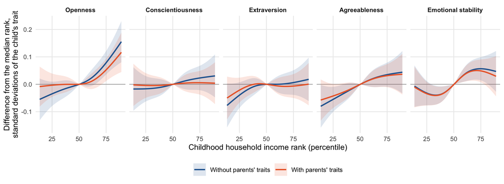

Figure 3: The income gradient across the income distribution, without and with the parents’ traits. Models of the pooled resource table with household income rank entered as a restricted cubic spline (knots at the 5th, 35th, 65th, and 95th percentiles). Curves: difference in the trait from a child at the median income rank. Shaded areas: pointwise 95 percent intervals for that difference, which have zero width at the median by construction.

```r
library(splines)
# m0: the pooled resource model of the table above
a$rank <- a$hinc_q * 25                                   # percentile scale
q  <- quantile(a$rank[!duplicated(a$pid)], c(.05, .35, .65, .95))   # over children
ms <- update(m0, . ~ . - hinc_q +
               ns(rank, knots = q[2:3], Boundary.knots = q[c(1, 4)]))
anova(refitML(m0), refitML(ms))                           # curve against the line
anova(refitML(update(m0, . ~ . - hinc_q)), refitML(ms))   # any gradient at all
```

**Other measures of money and other windows.** The income gradients do not depend on the window. With the window fixed at under 19 the coefficient for openness is 0.057, and at under 25 it is 0.085, against 0.065 in the main definition (Table 9). The parents’ earnings give a weaker gradient in openness, 0.023 per quarter of the rank, and it does not survive the parents’ traits (0.005). For emotional stability earnings do as well as income: 0.038 without the parents’ traits and 0.028 with them (Table 10). Household income includes pensions, transfers, and the earnings of other members, and it is divided by household size, so it describes the resources a child lives on more closely than the parents’ pay.

## 5.4 How much of the resource gradients goes with the parents’ traits?

The parents’ traits account for part of every resource gradient that is present, and for less than half of the income gradients (Table 7, Panel A). Of the income gradient in openness, 0.065 per quarter, 0.028 goes with the parents’ openness (standard error 0.006), which is 44 percent. For agreeableness the part is 0.009 of 0.042, or 21 percent. For emotional stability it is 0.004 of 0.032: richer families have more emotionally stable children for reasons other than the parents’ own emotional stability.

```
sub/code/04_mediation.R
```

```r
# for each resource (here household income), and again in each of 200 bootstrap
# samples of settlements:
total   <- fixef(m0)["hinc_q"]        # model without the parents' traits
direct  <- fixef(m1)["hinc_q"]        # model with them (ADE)
through <- total - direct             # ACME
# standard error: standard deviation of the quantity over the bootstrap samples
```

Table 7: Resource gradients in children’s traits: the part that goes with the parents’ traits (ACME), the direct part (ADE), and the total

|  | O | C | E | A | ES |
| --- | --- | --- | --- | --- | --- |
| **A. Household income, per quarter of rank** |  |  |  |  |  |
| ACME: parents' traits | 0.028*** (0.006) | 0.014*** (0.004) | 0.015*** (0.004) | 0.009* (0.005) | 0.004 (0.003) |
| ADE: direct part | 0.037** (0.015) | 0.004 (0.016) | 0.011 (0.017) | 0.034** (0.017) | 0.028 (0.017) |
| Total | 0.065*** (0.016) | 0.018 (0.016) | 0.026 (0.017) | 0.042** (0.020) | 0.032* (0.018) |
| Share through the parents' traits, % | 44 | – | – | 21 | – |
| **A. Either parent has a degree** |  |  |  |  |  |
| ACME: parents' traits | 0.036*** (0.007) | −0.000 (0.009) | 0.002 (0.006) | −0.008 (0.008) | 0.022*** (0.007) |
| ADE: direct part | 0.072*** (0.024) | −0.011 (0.026) | −0.021 (0.026) | 0.039 (0.032) | 0.002 (0.029) |
| Total | 0.109*** (0.024) | −0.011 (0.027) | −0.019 (0.027) | 0.031 (0.033) | 0.024 (0.032) |
| Share through the parents' traits, % | 33 | – | – | – | – |
| **A. Either parent in a high-skilled occupation** |  |  |  |  |  |
| ACME: parents' traits | 0.062*** (0.009) | 0.032*** (0.007) | 0.004 (0.006) | 0.026*** (0.007) | 0.011** (0.005) |
| ADE: direct part | 0.029 (0.023) | 0.069*** (0.025) | 0.011 (0.026) | −0.005 (0.023) | 0.018 (0.028) |
| Total | 0.092*** (0.022) | 0.101*** (0.025) | 0.014 (0.028) | 0.021 (0.024) | 0.030 (0.027) |
| Share through the parents' traits, % | 68 | 32 | – | – | – |
| **B. Household income, per quarter of rank** |  |  |  |  |  |
| ACME: mother's trait | 0.019*** (0.005) | 0.010** (0.004) | 0.009*** (0.004) | 0.009 (0.006) | −0.000 (0.003) |
| ACME: father's trait | 0.020*** (0.006) | 0.012** (0.005) | 0.004 (0.003) | 0.008 (0.006) | 0.004 (0.003) |
| ADE: direct part | 0.045** (0.023) | −0.005 (0.022) | 0.022 (0.019) | 0.020 (0.024) | 0.028 (0.022) |
| Total | 0.084*** (0.027) | 0.016 (0.023) | 0.036* (0.019) | 0.036 (0.028) | 0.032 (0.022) |
| Share through the parents' traits, % | 47 | – | – | – | – |
| **B. Mother has a degree** |  |  |  |  |  |
| ACME: mother's trait | 0.024*** (0.008) | 0.006 (0.007) | 0.008 (0.006) | −0.006 (0.012) | 0.012* (0.007) |
| ADE: direct part | 0.029 (0.037) | −0.059 (0.041) | 0.026 (0.044) | −0.023 (0.042) | 0.041 (0.050) |
| Total | 0.053 (0.037) | −0.053 (0.041) | 0.033 (0.045) | −0.029 (0.045) | 0.053 (0.052) |
| Share through the mother's trait, % | – | – | – | – | – |
| **B. Father has a degree** |  |  |  |  |  |
| ACME: father's trait | 0.016* (0.009) | 0.009 (0.007) | 0.006 (0.005) | 0.004 (0.009) | 0.016*** (0.005) |
| ADE: direct part | 0.042 (0.042) | 0.011 (0.038) | −0.074** (0.035) | 0.056 (0.041) | −0.022 (0.042) |
| Total | 0.059 (0.042) | 0.021 (0.038) | −0.068** (0.034) | 0.060 (0.041) | −0.006 (0.044) |
| Share through the father's trait, % | – | – | – | – | – |
| **B. Mother in a high-skilled occupation** |  |  |  |  |  |
| ACME: mother's trait | 0.060*** (0.011) | 0.031*** (0.008) | 0.001 (0.005) | 0.019* (0.010) | 0.011** (0.005) |
| ADE: direct part | 0.041 (0.030) | 0.079** (0.040) | 0.002 (0.035) | 0.035 (0.032) | −0.006 (0.033) |
| Total | 0.101*** (0.030) | 0.111*** (0.042) | 0.003 (0.036) | 0.054 (0.035) | 0.005 (0.033) |
| Share through the mother's trait, % | 59 | 28 | – | – | – |
| **B. Father in a high-skilled occupation** |  |  |  |  |  |
| ACME: father's trait | 0.061*** (0.013) | 0.033*** (0.010) | 0.012 (0.008) | 0.009 (0.008) | 0.015** (0.007) |
| ADE: direct part | −0.038 (0.035) | −0.012 (0.047) | 0.005 (0.034) | −0.028 (0.043) | −0.007 (0.039) |
| Total | 0.023 (0.032) | 0.021 (0.049) | 0.017 (0.036) | −0.020 (0.043) | 0.008 (0.039) |
| Share through the father's trait, % | – | – | – | – | – |

*Notes:* Models of the two resource tables. Panel A: parents pooled, 5,274 children. Panel B: mother and father entered separately, 3,177 children. Total: the resource's coefficient without the parents' traits. ADE: its coefficient with them. ACME: the difference. In Panel B a parent's part is the fall in the coefficient when that parent's trait is added, averaged over the two orders of adding the parents. For household income both parents' parts are shown and add up to the total with the direct part. For a parent's own education and occupation only the part that goes with that parent's own trait is shown, and the direct part is the rest of the total. Share: reported where the total differs from zero at the 5 percent level and the direct part has the same sign as the total. Standard errors from 200 bootstrap samples of settlements in parentheses; stars from the estimate divided by that standard error. * p < 0.10, ** p < 0.05, *** p < 0.01. ACME and ADE keep the terminology of mediation analysis; a causal reading needs the conditions of the methodology section.

Education and occupation show larger shares for openness. The parents’ openness accounts for 33 percent of the difference that goes with a parent’s degree (0.036 of 0.109) and for 68 percent of the difference that goes with a high-skilled occupation (0.062 of 0.092). For conscientiousness and occupation the share is 32 percent, and a direct part of 0.069 remains.

*Whose trait.* Household income belongs to both parents, and its gradient in openness divides evenly between them: 0.019 goes with the mother’s openness and 0.020 with the father’s (Table 7, Panel B; Figure 4). For a parent’s own education and occupation we ask only how much goes with that parent’s own trait. Children of mothers in high-skilled occupations are 0.101 standard deviations more open, and 0.060 of this goes with the mother’s openness. They are 0.111 more conscientious, of which 0.031 goes with her conscientiousness.

The father’s occupation has no total association with the child’s openness (0.023, standard error 0.032). Fathers in high-skilled occupations are more open themselves, so a part of 0.061 goes with the father’s openness, and the rest is −0.038, not distinguishable from zero.

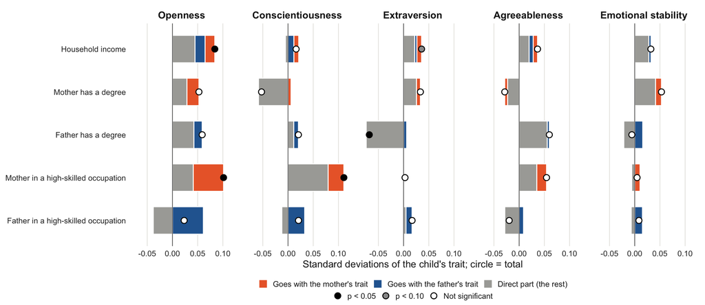

Figure 4: Decomposition of the resource gradients in children’s traits. Household income: the parts that go with the mother’s trait and with the father’s trait, and the direct part. A parent’s education and occupation: the part that goes with that parent’s own trait, and the rest. Models with mother and father entered separately. Bars to the right of zero raise the gradient and bars to the left lower it; together they add up to the total (circle). The circle is black where the total differs from zero at the 5 percent level, gray at the 10 percent level, and white where it is not significant. Income is per quarter of its within-year rank; education and occupation are indicators.

## 5.5 The parents’ education: levels and cohorts

The resource models compare parents with and without a degree. In the larger sample of people who report their parents’ education the whole range can be seen (Table 8). Openness rises at every step. Compared with people whose parents have secondary education or less, those with a parent who has specialized secondary education are 0.135 standard deviations more open, those with a parent in higher education 0.238, and those with a parent who has postgraduate study or an academic degree 0.407. Conscientiousness, agreeableness, and emotional stability are higher by 0.042 to 0.072 once the parents have more than secondary education, with little difference between specialized secondary and higher education. Extraversion does not vary with the parents’ education.

```
sub/code/10_education_recalled.R
```

```r
# recall: assessments of everyone who reported the parents' education;
# edu4: level of the more educated parent, reference "Secondary or below"
lv <- lmer(O ~ edu4 + female + age10 + age10_sq + age10_cu + round +
             (1 | site) + (1 | day) + (1 | visit) + (1 | pid),
           data = recall)
```

Table 8: Parents’ education in four levels and the respondent’s traits

| Variable | Openness | Conscientiousness | Extraversion | Agreeableness | Emotional stability |
| --- | --- | --- | --- | --- | --- |
| Parents' education: specialized secondary | 0.135*** | 0.053*** | 0.015 | 0.042*** | 0.072*** |
|  | (0.014) | (0.014) | (0.015) | (0.014) | (0.014) |
| Parents' education: higher | 0.238*** | 0.072*** | 0.007 | 0.061*** | 0.061*** |
|  | (0.015) | (0.015) | (0.016) | (0.015) | (0.015) |
| Parents' education: postgraduate or academic degree | 0.407*** | 0.135* | 0.038 | −0.008 | 0.137* |
|  | (0.077) | (0.080) | (0.086) | (0.076) | (0.080) |
| Female | 0.153*** | 0.215*** | 0.303*** | 0.239*** | −0.420*** |
|  | (0.010) | (0.011) | (0.012) | (0.010) | (0.011) |
| Age, decades from 20 | 0.025* | 0.433*** | −0.117*** | 0.050*** | 0.013 |
|  | (0.013) | (0.014) | (0.015) | (0.013) | (0.014) |
| Age squared | −0.013** | −0.098*** | 0.016*** | −0.015*** | −0.024*** |
|  | (0.006) | (0.006) | (0.006) | (0.006) | (0.006) |
| Age cubed | −0.001 | 0.004*** | −0.001* | 0.002*** | 0.002*** |
|  | (0.001) | (0.001) | (0.001) | (0.001) | (0.001) |
| Round 2020 | −0.023* | −0.091*** | 0.028** | −0.046*** | 0.143*** |
|  | (0.012) | (0.011) | (0.011) | (0.013) | (0.012) |
| Round 2025 | 0.044*** | −0.077*** | −0.012 | −0.149*** | 0.283*** |
|  | (0.013) | (0.012) | (0.012) | (0.014) | (0.012) |
| Constant | −0.163*** | −0.382*** | −0.022 | −0.197*** | 0.182*** |
|  | (0.036) | (0.029) | (0.026) | (0.034) | (0.023) |
| **Random part, fit, and sample** |  |  |  |  |  |
| Variance: settlement | 0.148 | 0.079 | 0.051 | 0.135 | 0.031 |
| Variance: interview day | 0.049 | 0.016 | 0.018 | 0.047 | 0.021 |
| Variance: household visit | 0.189 | 0.151 | 0.094 | 0.184 | 0.126 |
| Variance: person | 0.228 | 0.260 | 0.350 | 0.193 | 0.249 |
| Variance: residual | 0.368 | 0.428 | 0.460 | 0.435 | 0.484 |
| Marginal R-squared | 0.046 | 0.070 | 0.033 | 0.022 | 0.076 |
| Conditional R-squared | 0.642 | 0.573 | 0.543 | 0.572 | 0.509 |
| Log-likelihood | −52,148 | −53,127 | −54,302 | −53,357 | −54,026 |
| AIC | 104,326 | 106,285 | 108,634 | 106,744 | 108,081 |
| BIC | 104,456 | 106,414 | 108,763 | 106,873 | 108,210 |
| Assessments | 41,037 | 41,037 | 41,037 | 41,037 | 41,037 |
| People | 18,917 | 18,917 | 18,917 | 18,917 | 18,917 |
| Settlements | 164 | 164 | 164 | 164 | 164 |

*Notes:* Outcome: the person's score at each assessment, in standard deviations. Everyone with a score who reported the parents' education in 2018 or 2025 (the earlier report). Education of the more educated parent. Multilevel models with random intercepts for the settlement, the interview day within the settlement, the household visit, and the person. Standard errors in parentheses. Reference: secondary or below. Postgraduate study or an academic degree: 87 people. * p < 0.10, ** p < 0.05, *** p < 0.01.

Years of schooling tell the same story (Table 11 in the Appendix). One more year of the parents’ schooling goes with 0.041 standard deviations of openness. For openness a straight line describes the gradient well (test of the flexible curve against the line, p = 0.077). For conscientiousness, agreeableness, and emotional stability it does not (p = 0.022, = 0.002, and < 0.001): the gain comes between 11 and 13 years and little is added after that.

**Cohorts.** A parent with higher education was rare for the oldest respondents and common for the youngest: 9 percent of those born before 1960 had one, and 39 percent of those born in 1990 or later (Figure 5). The openness difference that goes with such a parent falls across cohorts, from 0.323 to 0.274, 0.274, and 0.116. The test that the education coefficients are the same in all cohorts is rejected for openness (p < 0.001) and not for the other traits (p 0.23 to 0.71; Table 13 in the Appendix).

```
sub/code/10_education_recalled.R
```

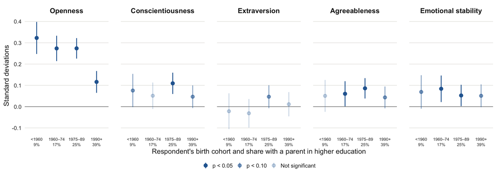

Figure 5: A parent with higher education and the respondent’s traits, by birth cohort. Markers: difference from respondents whose parents have secondary education or less, from the model with the levels of education interacted with the cohort; lines are 95 percent intervals. Solid markers differ from zero at the 5 percent level, lighter ones at the 10 percent level, and the faintest are not significant. The percentages under the cohorts are the shares of respondents with such a parent.

```r
c0 <- lmer(O ~ cohort + edu4 + female + age10 + age10_sq + age10_cu + round +
             (1 | site) + (1 | day) + (1 | visit) + (1 | pid),
           data = recall)
# the levels of education within each cohort
c1 <- lmer(O ~ cohort + edu4:cohort + female + age10 + age10_sq + age10_cu + round +
             (1 | site) + (1 | day) + (1 | visit) + (1 | pid),
           data = recall)
# are the education coefficients the same in all cohorts?
anova(refitML(c0), refitML(c1))
```

Two readings fit this pattern. A degree may have marked a more select group of parents when few had one. Or the parents’ education may show more in a person’s openness later in life, since the older cohorts are assessed at older ages. The data cannot separate the two. The fall is concentrated in the youngest cohort, whose members are assessed in their twenties and early thirties.

## 5.6 Children’s activities

Children’s activities outside the home are related to their later traits, and adding the parents’ traits changes these associations little (Figure 6; Table 14). The comparison is between a child who took part in half of the reports and one who never did, with the other activities held constant, among 1,846 children. With the parents’ traits in the model, children who attended clubs, sections, and courses score 0.069 standard deviations higher in openness, 0.107 higher in conscientiousness, and 0.055 higher in emotional stability. Dance and photography go with more openness (0.080), extraversion (0.097), and agreeableness (0.088), and with less emotional stability (−0.073). Children who took drawing or music lessons are also less emotionally stable later (−0.074). Foreign-language classes go with more conscientiousness (0.058), a difference that is marginally significant. Technical clubs, visits to theaters and museums, and outings with peers show no association with any trait.

```
sub/code/05_activities.R
```

```r
# act: children of the pooled resource sample with all seven activities recorded;
# each activity is the share of the reports that record it, divided by 0.5
m0 <- lmer(O ~ op_clubs + op_dance + op_arts + op_language + op_technical +
             op_culture + op_outings + report_age + report_count +
             hinc_q + p_tert + p_wc + settle + only_mother + only_father +
             disabled_by_first + recorded_sibship_size + recorded_birth_order +
             share_brothers +
             female + age10 + age10_sq + age10_cu + round +
             (1 | site) + (1 | day) + (1 | visit) + (1 | fam) + (1 | pid),
           data = act)
m1 <- update(m0, . ~ . + p_O_B + p_O_S + p_same)
```

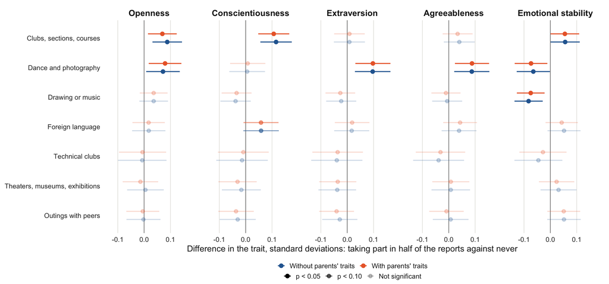

Figure 6: Children’s activities before the first assessment and later traits, without and with the parents’ traits. The seven activities enter the pooled resource model together. Markers compare taking part in half of the reports with never taking part; lines are 95 percent intervals. Solid markers differ from zero at the 5 percent level, lighter ones at the 10 percent level, and the faintest are not significant.

These associations are about as large as the difference that goes with one quarter of the income distribution. They are estimated with income and the parents’ education and occupation in the model. The activities are recorded before the first trait assessment, which settles the order in time and leaves selection open: a child who is already curious or diligent may be the one who joins a club and stays in it.

# 6 Discussion

# References

Bowles, S., Gintis, H., 2002. The inheritance of inequality. Journal of Economic Perspectives 16, 3–30.

Imai, K., Keele, L., Tingley, D., 2010. A general approach to causal mediation analysis. Psychological Methods 15, 309–334.

# 7 Supporting figures and tables

```
sub/code/08_same_visit.R
```

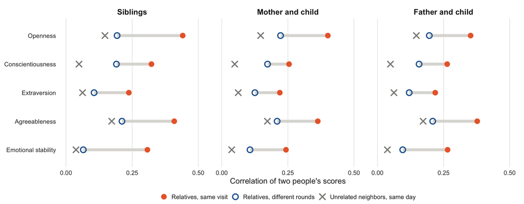

Figure 7: Relatives interviewed in the same visit look more alike. Correlation of two people’s scores, each taken relative to people of the same sex and age in the same round. Same visit: the two were scored in the same round in the same household. Different rounds: the two scores come from different rounds. Unrelated neighbors: two people from different households of the same settlement, not relatives, interviewed on the same day of the same round. Lines connect the two correlations for relatives.

[output not shown]

```r
# pairs: every pair of assessments of two relatives (a and b), with the scores
# taken relative to people of the same sex and age in the same round
pairs$cell <- ifelse(pairs$visit_a == pairs$visit_b, "same visit",
              ifelse(pairs$round_a != pairs$round_b, "different rounds", NA))
by(pairs, pairs$cell, function(d) cor(d$O_a, d$O_b))
# neighbors: two people of the same settlement, day, and round, from different
# households, not relatives
cor(neighbors$O_a, neighbors$O_b)
```

```r
# money_q: household income rank or the parents' earnings rank, per quarter, from
# the window shown; degree, occupation, and urban residence from the same window
m0 <- lmer(O ~ money_q + p_tert + p_wc + settle + only_mother + only_father +
             disabled_by_first + recorded_sibship_size + recorded_birth_order +
             share_brothers +
             female + age10 + age10_sq + age10_cu + round +
             (1 | site) + (1 | day) + (1 | visit) + (1 | fam) + (1 | pid),
           data = w)
m1 <- update(m0, . ~ . + p_O_B + p_O_S + p_same)
```

Table 9: The gradient in money under other measures and age windows

|  | O | C | E | A | ES | Children |
| --- | --- | --- | --- | --- | --- | --- |
| **Household income, window: flexible (main definition)** |  |  |  |  |  |  |
| Without parents' traits | 0.065*** (0.015) | 0.018 (0.015) | 0.026* (0.015) | 0.042*** (0.015) | 0.032** (0.015) | 5,274 |
| With parents' traits | 0.037** (0.014) | 0.004 (0.015) | 0.011 (0.015) | 0.034** (0.015) | 0.028* (0.014) | 5,274 |
| **Household income, window: under 19** |  |  |  |  |  |  |
| Without parents' traits | 0.057*** (0.016) | 0.005 (0.017) | 0.032* (0.017) | 0.038** (0.017) | 0.025 (0.016) | 4,573 |
| With parents' traits | 0.027* (0.016) | −0.009 (0.017) | 0.016 (0.017) | 0.031* (0.016) | 0.021 (0.016) | 4,573 |
| **Household income, window: under 25** |  |  |  |  |  |  |
| Without parents' traits | 0.085*** (0.016) | 0.029* (0.016) | 0.034** (0.016) | 0.054*** (0.016) | 0.030** (0.015) | 5,295 |
| With parents' traits | 0.054*** (0.015) | 0.013 (0.016) | 0.018 (0.016) | 0.042*** (0.015) | 0.023 (0.015) | 5,295 |
| **Parents' earnings, window: flexible (main definition)** |  |  |  |  |  |  |
| Without parents' traits | 0.023* (0.013) | 0.015 (0.014) | 0.006 (0.014) | 0.022 (0.014) | 0.038*** (0.013) | 5,314 |
| With parents' traits | 0.005 (0.013) | −0.004 (0.014) | 0.002 (0.014) | 0.015 (0.013) | 0.028** (0.013) | 5,314 |
| **Parents' earnings, window: under 19** |  |  |  |  |  |  |
| Without parents' traits | 0.031** (0.015) | 0.022 (0.016) | 0.025 (0.016) | 0.045*** (0.016) | 0.024 (0.015) | 4,612 |
| With parents' traits | 0.009 (0.015) | −0.002 (0.016) | 0.017 (0.016) | 0.035** (0.015) | 0.014 (0.015) | 4,612 |
| **Parents' earnings, window: under 25** |  |  |  |  |  |  |
| Without parents' traits | 0.025* (0.014) | 0.017 (0.014) | 0.008 (0.014) | 0.025* (0.014) | 0.038*** (0.014) | 5,337 |
| With parents' traits | 0.005 (0.013) | −0.005 (0.014) | 0.003 (0.014) | 0.018 (0.014) | 0.026* (0.013) | 5,337 |

*Notes:* Coefficient per quarter of the rank, from the pooled resource model (the models of Table 5), refitted with the money measure, the parents' degree and occupation, and urban residence taken from the window shown. Flexible: waves under 19, or under 25 for children with no wave under 19. Parents' earnings: each parent's monthly earnings ranked among mothers or fathers within the year, no job as the lowest rank, averaged over the parents and the window. Full models for the main window are in the next table. Standard errors in parentheses. * p < 0.10, ** p < 0.05, *** p < 0.01.

Table 10: Parents’ earnings and the child’s traits, without and with the parents’ traits: full models

| Variable | Openness Without | Openness With | Conscientiousness Without | Conscientiousness With | Extraversion Without | Extraversion With | Agreeableness Without | Agreeableness With | Emotional stability Without | Emotional stability With |
| --- | --- | --- | --- | --- | --- | --- | --- | --- | --- | --- |
| Parents' score, before the child's assessment | – | 0.216*** | – | 0.168*** | – | 0.162*** | – | 0.193*** | – | 0.109*** |
|  |  | (0.016) |  | (0.017) |  | (0.016) |  | (0.016) |  | (0.016) |
| Parents' score, same round | – | 0.302*** | – | 0.236*** | – | 0.205*** | – | 0.300*** | – | 0.172*** |
|  |  | (0.017) |  | (0.019) |  | (0.017) |  | (0.017) |  | (0.017) |
| Parents scored in the same round only | – | 0.099* | – | 0.126** | – | 0.070 | – | 0.058 | – | 0.195*** |
|  |  | (0.054) |  | (0.056) |  | (0.056) |  | (0.057) |  | (0.057) |
| Parents' earnings rank, per quarter | 0.023* | 0.005 | 0.015 | −0.004 | 0.006 | 0.002 | 0.022 | 0.015 | 0.038*** | 0.028** |
|  | (0.013) | (0.013) | (0.014) | (0.014) | (0.014) | (0.014) | (0.014) | (0.013) | (0.013) | (0.013) |
| Either parent: tertiary degree | 0.124*** | 0.081*** | 0.000 | −0.001 | −0.019 | −0.026 | 0.037 | 0.044 | 0.027 | 0.006 |
|  | (0.027) | (0.026) | (0.029) | (0.028) | (0.029) | (0.028) | (0.028) | (0.027) | (0.027) | (0.027) |
| Either parent: high-skilled occupation | 0.094*** | 0.036 | 0.093*** | 0.072** | 0.014 | 0.010 | 0.020 | −0.004 | 0.010 | 0.005 |
|  | (0.027) | (0.026) | (0.029) | (0.028) | (0.029) | (0.029) | (0.028) | (0.027) | (0.027) | (0.027) |
| Urban childhood residence | 0.081 | 0.015 | −0.061 | −0.073 | 0.109** | 0.095*** | −0.017 | −0.029 | −0.066 | −0.060 |
|  | (0.058) | (0.046) | (0.053) | (0.045) | (0.042) | (0.037) | (0.070) | (0.057) | (0.045) | (0.043) |
| Only the mother's records observed | −0.025 | −0.022 | −0.031 | −0.016 | −0.097*** | −0.093*** | −0.073*** | −0.067*** | −0.042* | −0.048* |
|  | (0.025) | (0.024) | (0.026) | (0.026) | (0.027) | (0.027) | (0.026) | (0.025) | (0.025) | (0.025) |
| Only the father's records observed | −0.066 | −0.098 | 0.014 | 0.092 | −0.025 | −0.006 | −0.066 | −0.049 | −0.082 | −0.075 |
|  | (0.103) | (0.100) | (0.108) | (0.106) | (0.112) | (0.110) | (0.105) | (0.102) | (0.104) | (0.102) |
| Registered disability by first assessment | −0.345*** | −0.348*** | −0.527*** | −0.513*** | −0.207*** | −0.218*** | −0.119* | −0.107* | −0.429*** | −0.436*** |
|  | (0.063) | (0.061) | (0.066) | (0.065) | (0.069) | (0.068) | (0.063) | (0.061) | (0.063) | (0.062) |
| Sibship size | −0.050*** | −0.045*** | −0.012 | −0.013 | −0.019 | −0.022* | −0.007 | −0.013 | 0.001 | −0.003 |
|  | (0.013) | (0.012) | (0.014) | (0.013) | (0.014) | (0.013) | (0.013) | (0.013) | (0.013) | (0.013) |
| Birth order | 0.015 | 0.017 | 0.010 | 0.011 | 0.011 | 0.014 | −0.025* | −0.023 | −0.018 | −0.016 |
|  | (0.015) | (0.015) | (0.016) | (0.016) | (0.017) | (0.017) | (0.015) | (0.015) | (0.015) | (0.015) |
| Share of brothers | 0.044* | 0.051** | 0.067*** | 0.062** | 0.056** | 0.055** | 0.029 | 0.028 | 0.059** | 0.056** |
|  | (0.025) | (0.024) | (0.026) | (0.025) | (0.027) | (0.026) | (0.025) | (0.024) | (0.025) | (0.025) |
| Female | 0.181*** | 0.177*** | 0.206*** | 0.207*** | 0.166*** | 0.159*** | 0.126*** | 0.127*** | −0.363*** | −0.366*** |
|  | (0.020) | (0.020) | (0.021) | (0.021) | (0.022) | (0.022) | (0.020) | (0.020) | (0.020) | (0.020) |
| Age, decades from 20 | 0.098*** | 0.109*** | 0.577*** | 0.590*** | −0.125*** | −0.119*** | 0.064*** | 0.061*** | −0.106*** | −0.105*** |
|  | (0.022) | (0.022) | (0.023) | (0.023) | (0.024) | (0.023) | (0.023) | (0.023) | (0.023) | (0.023) |
| Age squared | −0.103*** | −0.109*** | −0.327*** | −0.331*** | 0.033 | 0.033 | −0.053* | −0.052* | 0.020 | 0.024 |
|  | (0.029) | (0.029) | (0.030) | (0.030) | (0.030) | (0.030) | (0.031) | (0.030) | (0.030) | (0.030) |
| Age cubed | 0.017* | 0.017** | 0.051*** | 0.051*** | −0.007 | −0.007 | 0.009 | 0.009 | 0.002 | 0.000 |
|  | (0.009) | (0.008) | (0.009) | (0.009) | (0.009) | (0.009) | (0.009) | (0.009) | (0.009) | (0.009) |
| Round 2020 | −0.004 | 0.081 | 0.011 | 0.127** | 0.006 | 0.072 | 0.044* | 0.101* | 0.122*** | 0.306*** |
|  | (0.021) | (0.056) | (0.021) | (0.058) | (0.020) | (0.057) | (0.023) | (0.059) | (0.022) | (0.058) |
| Round 2025 | 0.085*** | 0.170*** | 0.029 | 0.145** | −0.014 | 0.046 | −0.033 | 0.025 | 0.315*** | 0.498*** |
|  | (0.023) | (0.057) | (0.023) | (0.059) | (0.023) | (0.059) | (0.025) | (0.060) | (0.024) | (0.059) |
| Constant | −0.070 | −0.045 | −0.360*** | −0.434*** | 0.008 | −0.034 | −0.145** | −0.171** | 0.167*** | 0.005 |
|  | (0.055) | (0.074) | (0.054) | (0.077) | (0.052) | (0.076) | (0.059) | (0.079) | (0.051) | (0.076) |
| **Random part, fit, and sample** |  |  |  |  |  |  |  |  |  |  |
| Variance: settlement | 0.070 | 0.036 | 0.050 | 0.031 | 0.024 | 0.014 | 0.112 | 0.068 | 0.032 | 0.027 |
| Variance: interview day | 0.080 | 0.079 | 0.033 | 0.039 | 0.012 | 0.012 | 0.064 | 0.063 | 0.056 | 0.055 |
| Variance: household visit | 0.108 | 0.090 | 0.132 | 0.116 | 0.111 | 0.102 | 0.135 | 0.110 | 0.118 | 0.106 |
| Variance: family | 0.090 | 0.059 | 0.103 | 0.084 | 0.050 | 0.033 | 0.116 | 0.091 | 0.092 | 0.081 |
| Variance: child | 0.136 | 0.135 | 0.158 | 0.157 | 0.270 | 0.268 | 0.066 | 0.061 | 0.101 | 0.099 |
| Variance: residual | 0.383 | 0.396 | 0.426 | 0.435 | 0.446 | 0.453 | 0.485 | 0.503 | 0.467 | 0.477 |
| Marginal R-squared | 0.040 | 0.092 | 0.097 | 0.124 | 0.023 | 0.048 | 0.009 | 0.057 | 0.066 | 0.084 |
| Conditional R-squared | 0.576 | 0.548 | 0.574 | 0.558 | 0.522 | 0.511 | 0.509 | 0.470 | 0.497 | 0.482 |
| Log-likelihood | −12,591 | −12,405 | −12,910 | −12,810 | −13,056 | −12,965 | −13,122 | −12,948 | −12,893 | −12,823 |
| AIC | 25,229 | 24,862 | 25,866 | 25,672 | 26,158 | 25,982 | 26,289 | 25,948 | 25,831 | 25,698 |
| BIC | 25,394 | 25,049 | 26,031 | 25,859 | 26,324 | 26,169 | 26,455 | 26,135 | 25,997 | 25,885 |
| Assessments | 9,886 | 9,886 | 9,886 | 9,886 | 9,886 | 9,886 | 9,886 | 9,886 | 9,886 | 9,886 |
| Children | 5,314 | 5,314 | 5,314 | 5,314 | 5,314 | 5,314 | 5,314 | 5,314 | 5,314 | 5,314 |
| Families | 3,859 | 3,859 | 3,859 | 3,859 | 3,859 | 3,859 | 3,859 | 3,859 | 3,859 | 3,859 |
| Settlements | 155 | 155 | 155 | 155 | 155 | 155 | 155 | 155 | 155 | 155 |

*Notes:* The pooled resource model with household income replaced by the parents' earnings. Outcome: the child's score at each assessment, in standard deviations. Multilevel models with random intercepts for the settlement, the interview day within the settlement, the household visit, the family, and the child; the same assessments without and with the parents' traits. Parents' scores are taken relative to people of the same sex and age in the same round, from before the child's assessment where such a score exists (the mean of the earlier ones) and otherwise from the same round, with a separate coefficient and an indicator. Income is household income per person ranked within the survey year, averaged over the childhood waves; all resources are measured before the first assessment. High-skilled occupation: ISCO-08 major groups 1 to 3. Standard errors in parentheses. * p < 0.10, ** p < 0.05, *** p < 0.01.

```
sub/code/10_education_recalled.R
```

```r
y1 <- lmer(O ~ edu_years + female + age10 + age10_sq + age10_cu + round +
             (1 | site) + (1 | day) + (1 | visit) + (1 | pid),
           data = recall)
y2 <- update(y1, . ~ . + I(edu_years^2))
```

Table 11: Parents’ years of schooling and the respondent’s traits

| Variable | Openness Linear | Openness Quadratic | Conscientiousness Linear | Conscientiousness Quadratic | Extraversion Linear | Extraversion Quadratic | Agreeableness Linear | Agreeableness Quadratic | Emotional stability Linear | Emotional stability Quadratic |
| --- | --- | --- | --- | --- | --- | --- | --- | --- | --- | --- |
| Parents' years of schooling | 0.041*** | 0.025* | 0.010*** | −0.016 | 0.004 | 0.026 | 0.008*** | −0.019 | 0.012*** | 0.016 |
|  | (0.002) | (0.014) | (0.002) | (0.015) | (0.002) | (0.016) | (0.002) | (0.014) | (0.002) | (0.015) |
| Parents' years of schooling, squared | – | 0.001 | – | 0.001* | – | −0.001 | – | 0.001* | – | −0.000 |
|  |  | (0.001) |  | (0.001) |  | (0.001) |  | (0.001) |  | (0.001) |
| Female | 0.153*** | 0.153*** | 0.215*** | 0.215*** | 0.304*** | 0.304*** | 0.239*** | 0.239*** | −0.419*** | −0.419*** |
|  | (0.010) | (0.010) | (0.011) | (0.011) | (0.012) | (0.012) | (0.010) | (0.010) | (0.011) | (0.011) |
| Age, decades from 20 | 0.021 | 0.022* | 0.432*** | 0.434*** | −0.116*** | −0.117*** | 0.049*** | 0.051*** | 0.015 | 0.015 |
|  | (0.013) | (0.013) | (0.014) | (0.014) | (0.015) | (0.015) | (0.013) | (0.013) | (0.014) | (0.014) |
| Age squared | −0.009 | −0.009* | −0.097*** | −0.098*** | 0.016*** | 0.017*** | −0.014** | −0.015*** | −0.024*** | −0.024*** |
|  | (0.006) | (0.006) | (0.006) | (0.006) | (0.006) | (0.006) | (0.006) | (0.006) | (0.006) | (0.006) |
| Age cubed | −0.001* | −0.001* | 0.004*** | 0.004*** | −0.001* | −0.001* | 0.002*** | 0.002*** | 0.002*** | 0.002*** |
|  | (0.001) | (0.001) | (0.001) | (0.001) | (0.001) | (0.001) | (0.001) | (0.001) | (0.001) | (0.001) |
| Round 2020 | −0.028** | −0.027** | −0.092*** | −0.091*** | 0.027** | 0.027** | −0.046*** | −0.046*** | 0.142*** | 0.142*** |
|  | (0.013) | (0.013) | (0.011) | (0.011) | (0.011) | (0.011) | (0.013) | (0.013) | (0.012) | (0.012) |
| Round 2025 | 0.034*** | 0.035*** | −0.078*** | −0.077*** | −0.014 | −0.015 | −0.150*** | −0.148*** | 0.280*** | 0.280*** |
|  | (0.013) | (0.013) | (0.012) | (0.012) | (0.012) | (0.012) | (0.014) | (0.014) | (0.012) | (0.012) |
| Constant | −0.575*** | −0.485*** | −0.478*** | −0.327*** | −0.063 | −0.189* | −0.263*** | −0.110 | 0.064* | 0.045 |
|  | (0.045) | (0.091) | (0.040) | (0.092) | (0.040) | (0.098) | (0.044) | (0.091) | (0.036) | (0.091) |
| **Random part, fit, and sample** |  |  |  |  |  |  |  |  |  |  |
| Variance: settlement | 0.143 | 0.143 | 0.079 | 0.079 | 0.051 | 0.051 | 0.135 | 0.135 | 0.031 | 0.031 |
| Variance: interview day | 0.049 | 0.049 | 0.016 | 0.016 | 0.018 | 0.018 | 0.047 | 0.047 | 0.020 | 0.020 |
| Variance: household visit | 0.189 | 0.189 | 0.151 | 0.151 | 0.094 | 0.094 | 0.184 | 0.184 | 0.125 | 0.125 |
| Variance: person | 0.226 | 0.227 | 0.260 | 0.260 | 0.350 | 0.350 | 0.193 | 0.193 | 0.249 | 0.249 |
| Variance: residual | 0.368 | 0.368 | 0.428 | 0.428 | 0.460 | 0.460 | 0.435 | 0.435 | 0.484 | 0.484 |
| Marginal R-squared | 0.048 | 0.048 | 0.069 | 0.070 | 0.033 | 0.033 | 0.021 | 0.021 | 0.076 | 0.076 |
| Conditional R-squared | 0.641 | 0.641 | 0.573 | 0.573 | 0.543 | 0.543 | 0.572 | 0.572 | 0.509 | 0.509 |
| Log-likelihood | −52,121 | −52,120 | −53,131 | −53,129 | −54,301 | −54,300 | −53,361 | −53,359 | −54,027 | −54,027 |
| AIC | 104,268 | 104,268 | 106,288 | 106,287 | 108,629 | 108,629 | 106,748 | 106,746 | 108,080 | 108,082 |
| BIC | 104,380 | 104,389 | 106,400 | 106,407 | 108,741 | 108,749 | 106,860 | 106,867 | 108,192 | 108,203 |
| Assessments | 41,037 | 41,037 | 41,037 | 41,037 | 41,037 | 41,037 | 41,037 | 41,037 | 41,037 | 41,037 |
| People | 18,917 | 18,917 | 18,917 | 18,917 | 18,917 | 18,917 | 18,917 | 18,917 | 18,917 | 18,917 |
| Settlements | 164 | 164 | 164 | 164 | 164 | 164 | 164 | 164 | 164 | 164 |

*Notes:* Outcome: the person's score at each assessment, in standard deviations. Everyone with a score who reported the parents' education in 2018 or 2025 (the earlier report). Education of the more educated parent. Multilevel models with random intercepts for the settlement, the interview day within the settlement, the household visit, and the person. Standard errors in parentheses. Years of schooling: 0 none, 4 primary, 8 incomplete secondary, 9 vocational courses, 10 vocational school without secondary education, 11 secondary school, 12 vocational school with secondary education, 13 specialized secondary, 16 higher, 19 postgraduate study or an academic degree. * p < 0.10, ** p < 0.05, *** p < 0.01.

```
sub/code/10_education_recalled.R
```

```r
library(splines)
y3 <- update(y1, . ~ . - edu_years + ns(edu_years, knots = c(11, 13)))
anova(refitML(y1), refitML(y3))      # flexible curve against the straight line
anova(refitML(y1), refitML(y2))      # squared term against the straight line
```

Table 12: The shape of the gradient in the parents’ years of schooling

|  | O | C | E | A | ES |
| --- | --- | --- | --- | --- | --- |
| **Difference from parents with 11 years of schooling** |  |  |  |  |  |
| 8 years | −0.110 (0.012) | −0.009 (0.013) | −0.027 (0.014) | 0.002 (0.012) | −0.036 (0.013) |
| 13 years | 0.101 (0.010) | 0.041 (0.011) | 0.010 (0.011) | 0.042 (0.010) | 0.061 (0.011) |
| 16 years | 0.219 (0.014) | 0.073 (0.015) | 0.004 (0.016) | 0.061 (0.014) | 0.065 (0.015) |
| 19 years | 0.302 (0.037) | 0.075 (0.039) | −0.018 (0.042) | 0.035 (0.037) | −0.011 (0.039) |
| **Tests, p-values** |  |  |  |  |  |
| Flexible curve against the straight line | 0.077 | 0.022 | 0.310 | 0.002 | 0.000 |
| Squared term against the straight line | 0.257 | 0.070 | 0.157 | 0.054 | 0.816 |

*Notes:* Differences predicted by the model with the years of schooling as a natural cubic spline with knots at 11 and 13 years; standard errors in parentheses. Tests: likelihood-ratio tests against the model with the years as a straight line. Sample and model as in the previous table.

Table 13: Parents’ education by the respondent’s birth cohort: full models

| Variable | Openness | Conscientiousness | Extraversion | Agreeableness | Emotional stability |
| --- | --- | --- | --- | --- | --- |
| Born before 1960 × specialized secondary | 0.214*** | 0.035 | −0.052 | 0.014 | 0.068* |
|  | (0.034) | (0.036) | (0.038) | (0.034) | (0.036) |
| Born before 1960 × higher | 0.323*** | 0.076* | −0.022 | 0.051 | 0.069* |
|  | (0.038) | (0.040) | (0.043) | (0.038) | (0.040) |
| Born before 1960 × postgraduate or academic degree | 0.690*** | 0.289 | −0.082 | −0.582*** | 0.469** |
|  | (0.221) | (0.231) | (0.249) | (0.220) | (0.232) |
| Born 1960–1974 × specialized secondary | 0.164*** | 0.069** | −0.010 | 0.043 | 0.069** |
|  | (0.028) | (0.029) | (0.031) | (0.027) | (0.029) |
| Born 1960–1974 × higher | 0.274*** | 0.051 | −0.031 | 0.060** | 0.084*** |
|  | (0.030) | (0.032) | (0.034) | (0.030) | (0.032) |
| Born 1960–1974 × postgraduate or academic degree | 0.580*** | 0.294 | −0.080 | 0.272 | 0.174 |
|  | (0.192) | (0.201) | (0.218) | (0.190) | (0.202) |
| Born 1975–1989 × specialized secondary | 0.111*** | 0.077*** | 0.070*** | 0.060*** | 0.048** |
|  | (0.023) | (0.024) | (0.026) | (0.023) | (0.024) |
| Born 1975–1989 × higher | 0.274*** | 0.109*** | 0.047* | 0.086*** | 0.052** |
|  | (0.025) | (0.026) | (0.028) | (0.024) | (0.026) |
| Born 1975–1989 × postgraduate or academic degree | 0.346*** | 0.041 | 0.035 | −0.009 | 0.051 |
|  | (0.128) | (0.134) | (0.146) | (0.127) | (0.135) |
| Born 1990 or later × specialized secondary | 0.065** | 0.026 | 0.006 | 0.036 | 0.100*** |
|  | (0.028) | (0.029) | (0.031) | (0.028) | (0.029) |
| Born 1990 or later × higher | 0.116*** | 0.047* | 0.011 | 0.043* | 0.051* |
|  | (0.026) | (0.027) | (0.029) | (0.026) | (0.027) |
| Born 1990 or later × postgraduate or academic degree | 0.239* | 0.102 | 0.132 | 0.056 | 0.088 |
|  | (0.124) | (0.130) | (0.140) | (0.124) | (0.131) |
| Born 1960–1974 | −0.021 | −0.099*** | 0.042 | −0.021 | 0.102*** |
|  | (0.027) | (0.028) | (0.030) | (0.027) | (0.028) |
| Born 1975–1989 | 0.037 | −0.083* | 0.099** | −0.017 | 0.117*** |
|  | (0.042) | (0.043) | (0.046) | (0.042) | (0.044) |
| Born 1990 or later | 0.182*** | 0.113* | 0.147** | 0.075 | 0.089 |
|  | (0.056) | (0.058) | (0.062) | (0.056) | (0.059) |
| Female | 0.153*** | 0.215*** | 0.303*** | 0.238*** | −0.419*** |
|  | (0.010) | (0.011) | (0.012) | (0.010) | (0.011) |
| Age, decades from 20 | 0.066*** | 0.539*** | −0.116*** | 0.092*** | −0.014 |
|  | (0.019) | (0.020) | (0.021) | (0.019) | (0.020) |
| Age squared | −0.017** | −0.120*** | 0.031*** | −0.022*** | −0.011 |
|  | (0.007) | (0.008) | (0.008) | (0.008) | (0.008) |
| Age cubed | −0.001 | 0.005*** | −0.003*** | 0.002*** | 0.001 |
|  | (0.001) | (0.001) | (0.001) | (0.001) | (0.001) |
| Round 2020 | −0.030** | −0.097*** | 0.017 | −0.051*** | 0.137*** |
|  | (0.013) | (0.012) | (0.012) | (0.013) | (0.012) |
| Round 2025 | 0.031** | −0.089*** | −0.035** | −0.158*** | 0.270*** |
|  | (0.015) | (0.014) | (0.014) | (0.015) | (0.015) |
| Constant | −0.261*** | −0.451*** | −0.163*** | −0.252*** | 0.091 |
|  | (0.061) | (0.059) | (0.061) | (0.060) | (0.057) |
| **Random part, fit, and sample** |  |  |  |  |  |
| Variance: settlement | 0.148 | 0.079 | 0.051 | 0.135 | 0.031 |
| Variance: interview day | 0.049 | 0.016 | 0.018 | 0.047 | 0.021 |
| Variance: household visit | 0.190 | 0.150 | 0.094 | 0.184 | 0.126 |
| Variance: person | 0.227 | 0.260 | 0.350 | 0.193 | 0.248 |
| Variance: residual | 0.368 | 0.427 | 0.459 | 0.435 | 0.484 |
| Marginal R-squared | 0.047 | 0.069 | 0.034 | 0.022 | 0.077 |
| Conditional R-squared | 0.643 | 0.573 | 0.544 | 0.572 | 0.509 |
| Log-likelihood | −52,119 | −53,089 | −54,290 | −53,346 | −54,013 |
| AIC | 104,291 | 106,232 | 108,634 | 106,746 | 108,080 |
| BIC | 104,524 | 106,465 | 108,866 | 106,979 | 108,313 |
| Assessments | 41,037 | 41,037 | 41,037 | 41,037 | 41,037 |
| People | 18,917 | 18,917 | 18,917 | 18,917 | 18,917 |
| Settlements | 164 | 164 | 164 | 164 | 164 |

*Notes:* Outcome: the person's score at each assessment, in standard deviations. Everyone with a score who reported the parents' education in 2018 or 2025 (the earlier report). Education of the more educated parent. Multilevel models with random intercepts for the settlement, the interview day within the settlement, the household visit, and the person. Standard errors in parentheses. Each education coefficient is the difference from respondents of the same cohort whose parents have secondary education or less. Test that the education coefficients are the same in all cohorts (likelihood ratio, 9 degrees of freedom), p-values: O 0.000, C 0.667, E 0.268, A 0.225, ES 0.714 . * p < 0.10, ** p < 0.05, *** p < 0.01.

Table 14: Children’s activities and later traits, without and with the parents’ traits: full models

| Variable | Openness Without | Openness With | Conscientiousness Without | Conscientiousness With | Extraversion Without | Extraversion With | Agreeableness Without | Agreeableness With | Emotional stability Without | Emotional stability With |
| --- | --- | --- | --- | --- | --- | --- | --- | --- | --- | --- |
| Parents' score, before the child's assessment | – | 0.235*** | – | 0.168*** | – | 0.169*** | – | 0.217*** | – | 0.141*** |
|  |  | (0.027) |  | (0.029) |  | (0.027) |  | (0.026) |  | (0.026) |
| Parents' score, same round | – | 0.189*** | – | 0.168*** | – | 0.099** | – | 0.259*** | – | 0.186*** |
|  |  | (0.040) |  | (0.046) |  | (0.041) |  | (0.042) |  | (0.038) |
| Parents scored in the same round only | – | 0.044 | – | 0.117 | – | 0.023 | – | −0.135 | – | 0.313** |
|  |  | (0.133) |  | (0.142) |  | (0.138) |  | (0.142) |  | (0.132) |
| Clubs, sections, courses | 0.088*** | 0.069** | 0.115*** | 0.107*** | 0.008 | 0.008 | 0.040 | 0.033 | 0.056** | 0.055** |
|  | (0.029) | (0.028) | (0.030) | (0.030) | (0.030) | (0.030) | (0.030) | (0.029) | (0.028) | (0.028) |
| Dance and photography | 0.072** | 0.080** | 0.006 | 0.008 | 0.097*** | 0.097*** | 0.087** | 0.088*** | −0.065** | −0.073** |
|  | (0.032) | (0.032) | (0.035) | (0.034) | (0.034) | (0.034) | (0.034) | (0.033) | (0.032) | (0.032) |
| Drawing or music | 0.036 | 0.036 | −0.038 | −0.034 | −0.023 | −0.026 | −0.006 | −0.011 | −0.083*** | −0.074*** |
|  | (0.028) | (0.027) | (0.029) | (0.029) | (0.029) | (0.029) | (0.029) | (0.028) | (0.027) | (0.027) |
| Foreign language | 0.018 | 0.017 | 0.058* | 0.058* | 0.017 | 0.019 | 0.039 | 0.043 | 0.052 | 0.043 |
|  | (0.032) | (0.031) | (0.034) | (0.034) | (0.034) | (0.034) | (0.034) | (0.033) | (0.032) | (0.031) |
| Technical clubs | −0.007 | −0.006 | −0.014 | −0.009 | −0.039 | −0.036 | −0.039 | −0.031 | −0.045 | −0.028 |
|  | (0.047) | (0.046) | (0.050) | (0.049) | (0.050) | (0.049) | (0.049) | (0.048) | (0.046) | (0.046) |
| Theaters, museums, exhibitions | 0.005 | −0.014 | −0.016 | −0.031 | −0.038 | −0.036 | 0.008 | 0.008 | 0.031 | 0.024 |
|  | (0.035) | (0.034) | (0.038) | (0.037) | (0.036) | (0.036) | (0.037) | (0.036) | (0.035) | (0.034) |
| Outings with peers | −0.002 | −0.005 | −0.030 | −0.037 | −0.028 | −0.040 | 0.007 | −0.009 | 0.052 | 0.051 |
|  | (0.033) | (0.032) | (0.035) | (0.034) | (0.034) | (0.034) | (0.035) | (0.033) | (0.032) | (0.032) |
| Mean age at the child reports | 0.009 | 0.003 | 0.005 | 0.006 | 0.033 | 0.035 | 0.015 | 0.003 | −0.026 | −0.027 |
|  | (0.033) | (0.033) | (0.035) | (0.035) | (0.035) | (0.035) | (0.035) | (0.034) | (0.033) | (0.033) |
| Number of child reports | −0.004 | −0.003 | −0.011 | −0.008 | −0.005 | −0.001 | −0.014 | −0.021 | −0.012 | −0.005 |
|  | (0.018) | (0.018) | (0.019) | (0.019) | (0.019) | (0.019) | (0.019) | (0.019) | (0.018) | (0.018) |
| Household income rank, per quarter | 0.076*** | 0.037 | −0.010 | −0.016 | 0.050* | 0.028 | 0.081*** | 0.069** | 0.032 | 0.027 |
|  | (0.027) | (0.027) | (0.029) | (0.029) | (0.028) | (0.028) | (0.029) | (0.028) | (0.027) | (0.026) |
| Either parent: tertiary degree | 0.106** | 0.090* | 0.005 | −0.015 | −0.012 | −0.003 | −0.018 | −0.018 | −0.043 | −0.051 |
|  | (0.048) | (0.046) | (0.051) | (0.050) | (0.049) | (0.049) | (0.050) | (0.048) | (0.047) | (0.046) |
| Either parent: high-skilled occupation | 0.055 | 0.008 | 0.073 | 0.065 | 0.037 | 0.031 | 0.033 | 0.014 | 0.053 | 0.036 |
|  | (0.046) | (0.045) | (0.049) | (0.048) | (0.047) | (0.047) | (0.048) | (0.046) | (0.045) | (0.045) |
| Urban childhood residence | −0.095 | −0.115* | −0.198*** | −0.196*** | 0.125** | 0.114** | −0.187*** | −0.178*** | −0.111* | −0.103* |
|  | (0.063) | (0.060) | (0.067) | (0.063) | (0.056) | (0.055) | (0.072) | (0.063) | (0.059) | (0.058) |
| Only the mother's records observed | −0.020 | −0.033 | −0.099** | −0.102** | −0.016 | −0.019 | −0.007 | −0.001 | −0.077* | −0.075 |
|  | (0.047) | (0.045) | (0.050) | (0.049) | (0.049) | (0.048) | (0.049) | (0.047) | (0.046) | (0.046) |
| Only the father's records observed | −0.138 | −0.243 | 0.087 | 0.106 | −0.323 | −0.262 | −0.062 | −0.049 | −0.237 | −0.165 |
|  | (0.202) | (0.197) | (0.216) | (0.213) | (0.208) | (0.206) | (0.212) | (0.206) | (0.200) | (0.197) |
| Registered disability by first assessment | −0.121 | −0.139 | −0.137 | −0.131 | −0.105 | −0.141 | 0.024 | 0.009 | −0.306** | −0.280** |
|  | (0.123) | (0.120) | (0.131) | (0.130) | (0.130) | (0.129) | (0.129) | (0.126) | (0.122) | (0.120) |
| Sibship size | −0.041* | −0.042** | 0.010 | 0.007 | −0.020 | −0.025 | −0.007 | −0.010 | 0.021 | 0.016 |
|  | (0.021) | (0.020) | (0.022) | (0.022) | (0.021) | (0.021) | (0.022) | (0.021) | (0.021) | (0.020) |
| Birth order | 0.034 | 0.038 | 0.019 | 0.023 | 0.072** | 0.073** | −0.007 | −0.005 | −0.013 | −0.011 |
|  | (0.028) | (0.027) | (0.030) | (0.029) | (0.029) | (0.029) | (0.029) | (0.029) | (0.027) | (0.027) |
| Share of brothers | 0.070* | 0.059 | −0.002 | −0.002 | 0.031 | 0.026 | 0.113*** | 0.114*** | −0.007 | 0.002 |
|  | (0.042) | (0.041) | (0.045) | (0.044) | (0.044) | (0.044) | (0.044) | (0.043) | (0.042) | (0.041) |
| Female | 0.164*** | 0.161*** | 0.215*** | 0.214*** | 0.036 | 0.033 | 0.045 | 0.054 | −0.248*** | −0.259*** |
|  | (0.041) | (0.040) | (0.044) | (0.043) | (0.043) | (0.043) | (0.043) | (0.042) | (0.041) | (0.040) |
| Age, decades from 20 | 0.045 | 0.070 | 0.639*** | 0.671*** | −0.564*** | −0.539*** | −0.006 | −0.005 | 0.216 | 0.292* |
|  | (0.159) | (0.159) | (0.170) | (0.171) | (0.165) | (0.166) | (0.172) | (0.172) | (0.158) | (0.159) |
| Age squared | −0.377 | −0.462 | −1.131* | −1.114* | 0.730 | 0.738 | 0.792 | 0.717 | −0.276 | −0.241 |
|  | (0.579) | (0.579) | (0.624) | (0.624) | (0.605) | (0.604) | (0.630) | (0.628) | (0.579) | (0.579) |
| Age cubed | −0.008 | −0.096 | −1.321 | −1.252 | 1.917* | 1.933* | 0.936 | 0.789 | −1.131 | −1.071 |
|  | (0.991) | (0.987) | (1.064) | (1.063) | (1.035) | (1.033) | (1.073) | (1.068) | (0.990) | (0.988) |
| Round 2020 | 0.019 | 0.052 | 0.036 | 0.136 | 0.060 | 0.074 | 0.087 | −0.043 | 0.075 | 0.356*** |
|  | (0.055) | (0.133) | (0.058) | (0.142) | (0.056) | (0.138) | (0.059) | (0.143) | (0.054) | (0.132) |
| Round 2025 | 0.059 | 0.078 | 0.010 | 0.099 | 0.104 | 0.102 | 0.022 | −0.106 | 0.182** | 0.433*** |
|  | (0.083) | (0.140) | (0.089) | (0.149) | (0.086) | (0.145) | (0.089) | (0.149) | (0.082) | (0.138) |
| Constant | −0.336 | −0.098 | −0.280 | −0.328 | −0.623 | −0.592 | −0.572 | −0.208 | 0.492 | 0.271 |
|  | (0.474) | (0.482) | (0.504) | (0.517) | (0.500) | (0.514) | (0.501) | (0.509) | (0.469) | (0.480) |
| **Random part, fit, and sample** |  |  |  |  |  |  |  |  |  |  |
| Variance: settlement | 0.042 | 0.036 | 0.045 | 0.036 | 0.019 | 0.018 | 0.065 | 0.041 | 0.031 | 0.030 |
| Variance: interview day | 0.118 | 0.104 | 0.030 | 0.029 | 0.021 | 0.017 | 0.124 | 0.117 | 0.080 | 0.081 |
| Variance: household visit | 0.066 | 0.077 | 0.065 | 0.073 | 0.130 | 0.123 | 0.095 | 0.105 | 0.005 | 0.015 |
| Variance: family | 0.084 | 0.058 | 0.153 | 0.136 | 0.004 | 0.000 | 0.066 | 0.037 | 0.129 | 0.105 |
| Variance: child | 0.121 | 0.116 | 0.079 | 0.079 | 0.250 | 0.240 | 0.118 | 0.115 | 0.074 | 0.075 |
| Variance: residual | 0.356 | 0.365 | 0.513 | 0.510 | 0.412 | 0.423 | 0.435 | 0.440 | 0.442 | 0.437 |
| Marginal R-squared | 0.061 | 0.096 | 0.072 | 0.089 | 0.024 | 0.041 | 0.027 | 0.066 | 0.055 | 0.075 |
| Conditional R-squared | 0.575 | 0.563 | 0.463 | 0.462 | 0.519 | 0.505 | 0.532 | 0.519 | 0.452 | 0.456 |
| Log-likelihood | −3,636 | −3,594 | −3,815 | −3,794 | −3,755 | −3,734 | −3,835 | −3,790 | −3,604 | −3,579 |
| AIC | 7,335 | 7,257 | 7,693 | 7,658 | 7,574 | 7,538 | 7,734 | 7,650 | 7,272 | 7,228 |
| BIC | 7,526 | 7,466 | 7,884 | 7,867 | 7,765 | 7,747 | 7,925 | 7,859 | 7,463 | 7,437 |
| Assessments | 2,897 | 2,897 | 2,897 | 2,897 | 2,897 | 2,897 | 2,897 | 2,897 | 2,897 | 2,897 |
| Children | 1,846 | 1,846 | 1,846 | 1,846 | 1,846 | 1,846 | 1,846 | 1,846 | 1,846 | 1,846 |
| Families | 1,529 | 1,529 | 1,529 | 1,529 | 1,529 | 1,529 | 1,529 | 1,529 | 1,529 | 1,529 |
| Settlements | 141 | 141 | 141 | 141 | 141 | 141 | 141 | 141 | 141 | 141 |

*Notes:* Each activity is the share of the child questionnaires before age 18 and before the first assessment that record it, scaled so that one unit is taking part in half of the reports against never. The seven activities enter together. Children of the pooled resource sample with all seven activities recorded. Outcome: the child's score at each assessment, in standard deviations. Multilevel models with random intercepts for the settlement, the interview day within the settlement, the household visit, the family, and the child; the same assessments without and with the parents' traits. Parents' scores are taken relative to people of the same sex and age in the same round, from before the child's assessment where such a score exists (the mean of the earlier ones) and otherwise from the same round, with a separate coefficient and an indicator. Income is household income per person ranked within the survey year, averaged over the childhood waves; all resources are measured before the first assessment. High-skilled occupation: ISCO-08 major groups 1 to 3. Standard errors in parentheses. * p < 0.10, ** p < 0.05, *** p < 0.01.

## Footnotes

[^1]: Source: “Russia Longitudinal Monitoring survey, RLMS HSE”, conducted by National Research University “Higher School of Economics” and OOO “Demoscope” together with the Institute of Sociology of the Federal Center of Theoretical and Applied Sociology of the Russian Academy of Sciences. (RLMS HSE web site: https://www.hse.ru/rlms)